# League Cup Match day 4 Season 2627

Result

| Liverpool Gakpo 43' (pen) | 1 – 1 Liverpool win 6–5 on penalties | Chelsea Rogers 40' (pen) |
| --- | --- | --- |

Liverpool vs Chelsea - 28-10-2026 | League Cup MD 4

Liverpool drew 1–1 with Chelsea (xG 2.12 vs 1.82); Liverpool win 6–5 on penalties. Liverpool's peak field tilt was 64% in the 1st Quarter. Chelsea's peak field tilt was 60% in the 2nd Quarter.

xG

LIV 2.12 – 1.82 CHE

xGOT

LIV 1.76 – 1.82 CHE

Field Tilt %

LIV 52% – 48% CHE

PPDA (lower = more intense press)

LIV 15.35 – 25.77 CHE

EPV

LIV 2.19 – 2.08 CHE

EPV to xG Conversion %

LIV 97% – 88% CHE

xG Race

[figure not shown]

Match Momentum

[figure not shown]

Threat Race

[figure not shown]

Field Tilt Momentum

[figure not shown]

Match Report

Summary

- Liverpool drew 1–1 with Chelsea (xG 2.12 vs 1.82); Liverpool win 6–5 on penalties. Liverpool's peak field tilt was 64% in the 1st Quarter. Chelsea's peak field tilt was 60% in the 2nd Quarter.

Set pieces

- **Liverpool** took 7 corners, winning first contact on 2 of 7 direct deliveries. Set pieces produced 5 shots worth 0.57 xG (27% of their xG).

- **Chelsea** took 5 corners (2 short), winning first contact on 1 of 3 direct deliveries. Set pieces produced 3 shots worth 0.41 xG (23% of their xG).

Transitions

- **Liverpool** won the ball in open play 105 times (11 in the attacking third) and had 2 shots within 15 seconds of a regain, worth 0.09 xG.

- **Chelsea** won the ball in open play 115 times (16 in the attacking third) and had 5 shots within 15 seconds of a regain, worth 0.58 xG.

Defensive shape

- **Liverpool**'s defensive actions dropped from an average of 49.1m to 30.6m from their own goal between the 1st Quarter and the 2nd Quarter (score 0-0 at the start of the 2nd Quarter), while **Chelsea** went from 30.5m to 38.5m over the 3rd Quarter to 4th Quarter. Standard PPDA: Liverpool 15.35, Chelsea 25.77 (lower = more pressing).

Passing chains

- **Liverpool** strung together 7 moves of 10+ completed passes (27% of their completed passes came in those moves, 1 ended in a shot). Their longest move was 17 passes (1').

- **Chelsea** strung together 7 moves of 10+ completed passes (26% of their completed passes came in those moves, 0 ended in a shot). Their longest move was 19 passes (36').

Threat areas

- **Liverpool** generated most threat from the final third, left wing (0.71 EPV, 33%), followed by the final third, right wing (0.31).

- **Chelsea** generated most threat from the final third, left wing (0.61 EPV, 29%), followed by the final third, central (0.29).

Pass maps

- **Liverpool**'s most used combination was van Dijk to Nyoni (14 completed passes), and Nyoni was the hub of the pass map, involved in 120 completed passes.

- **Chelsea**'s most used combination was Lacroix to Penders (10 completed passes), and Henderson was the hub of the pass map, involved in 89 completed passes.

Liverpool Line up

Liverpool vs Chelsea - 28-10-2026

| Mins Played | Shirt Number | Player |
| --- | --- | --- |
| Keeper |  |  |
| 111 | 25 | Giorgi Mamardashvili |
| Defender |  |  |
| 111 | 2 | Joe Gomez |
| 111 | 21 | Kostas Tsimikas |
| 111 | 33 | Ronald Araujo |
| 76 | 4 | Virgil van Dijk |
| 35 | 5 | Jérémy Jacquet |
| Midfielder |  |  |
| 111 | 38 | Ryan Gravenberch |
| 86 | 73 | Rio Ngumoha |
| 85 | 42 | Trey Nyoni |
| 63 | 53 | James McConnell |
| 63 | 67 | Lewis Koumas |
| 48 | 29 | Bradley Barcola |
| 48 | 7 | Florian Wirtz |
| 26 | 10 | Alexis Mac Allister |
| Forward |  |  |
| 111 | 18 | Cody Gakpo |
| 25 | 9 | Alexander Isak |
| Substitute |  |  |
| 0 | 1 | Alisson Becker |
| 0 | 3 | Wataru Endo |
| 0 | 14 | Federico Chiesa |
| 0 | 44 | Luke Chambers |

X @Barts78 · Bluesky @barts78 · Mastodon @DrBarts · GitHub Barts78 · LinkedIn Phil-barter · Data: Opta

Chelsea Line up

Liverpool vs Chelsea - 28-10-2026

|  | Shirt Number | Mins Played |
| --- | --- | --- |
| Keeper |  |  |
| Mike Penders | 39 | 111 |
| Defender |  |  |
| Josh Acheampong | 34 | 111 |
| Wesley Fofana | 3 | 111 |
| Malo Gusto | 27 | 72 |
| Levi Colwill | 6 | 66 |
| Maxence Lacroix | 5 | 45 |
| Marco Palestra | 2 | 39 |
| Midfielder |  |  |
| Jordan Henderson | 14 | 111 |
| Roméo Lavia | 45 | 111 |
| Moisés Caicedo | 25 | 72 |
| Valentín Barco | 4 | 39 |
| Forward |  |  |
| Morgan Rogers | 17 | 111 |
| Pedro Neto | 7 | 111 |
| Danny Welbeck | 18 | 72 |
| Emmanuel Emegha | 22 | 39 |
| Substitute |  |  |
| Teddy Sharman-Lowe | 28 | 0 |
| Olutayo Subuloye | 37 | 0 |
| Mahdi Nicoll-Jazuli | 32 | 0 |
| Estêvão | 41 | 0 |
| Geovany Quenda | 23 | 0 |

X @Barts78 · Bluesky @barts78 · Mastodon @DrBarts · GitHub Barts78 · LinkedIn Phil-barter · Data: Opta

**Match Summary tables**

**Match Summary - Full Time**

Liverpool vs Chelsea - 28-10-2026

| Possession Possession % | Possession On Ball Time | Possession Touches | Possession PKBox Touches | Possession Field Tilt % | Shots Total Shots | Shots OFF Shots | Shots SoT | Shots 6yrd box Shots | Shots PK Box Shots | Shots Outside Box Shots | Shots Blocked Shots | Shots BCs | Shots Goals | Shots xG | Shots NPxG | Shots xGOT | Threat EPV | Threat EPV % xG Con. | Threat EPV % NPxG Con. | Passes Attempted Passes | Passes Successful Passes | Passes Pass Success % | Passes Long Passes | Passes Long Ball Rate | Passes Crosses | Passes Cross Success % | Passes Corners | Passes Short Corners | PPDO | … |
| --- | --- | --- | --- | --- | --- | --- | --- | --- | --- | --- | --- | --- | --- | --- | --- | --- | --- | --- | --- | --- | --- | --- | --- | --- | --- | --- | --- | --- | --- | --- |
| Chelsea |  |  |  |  |  |  |  |  |  |  |  |  |  |  |  |  |  |  |  |  |  |  |  |  |  |  |  |  |  | … |
| 49.8% | 39.20 | 620 | 21 | 48.2% | 11 | 4 | 4 | 1 | 8 | 3 | 3 | 2 | 1 | 1.82 | 1.03 | 1.82 | 2.08 | 87.4% | 49.4% | 422 | 334 | 79.1% | 43 | 10.2% | 12 | 16.7% | 5 | 2 |  | … |
| Liverpool |  |  |  |  |  |  |  |  |  |  |  |  |  |  |  |  |  |  |  |  |  |  |  |  |  |  |  |  |  | … |
| 50.2% | 35.90 | 624 | 21 | 51.8% | 10 | 1 | 4 | 2 | 8 | 2 | 5 | 4 | 1 | 2.12 | 1.33 | 1.76 | 2.19 | 96.8% | 60.8% | 441 | 347 | 78.7% | 56 | 12.7% | 21 | 23.8% | 7 | 0 | 1000 | … |

X @Barts78 · Bluesky @barts78 · Mastodon @DrBarts · GitHub Barts78 · LinkedIn Phil-barter · Data: Opta

**Match Summary - By Half**

Liverpool vs Chelsea - 28-10-2026

|  | Possession Possession % | Possession On Ball Time | Possession Touches | Possession PKBox Touches | Possession Field Tilt % | Shots Total Shots | Shots OFF Shots | Shots SoT | Shots 6yrd box Shots | Shots PK Box Shots | Shots Outside Box Shots | Shots Blocked Shots | Shots BCs | Shots Goals | Shots xG | Shots NPxG | Shots xGOT | Threat EPV | Threat EPV % xG Con. | Threat EPV % NPxG Con. | Passes Attempted Passes | Passes Successful Passes | Passes Pass Success % | Passes Long Passes | Passes Long Ball Rate | Passes Crosses | Passes Cross Success % | Passes Corners | Passes Short Corners | … |
| --- | --- | --- | --- | --- | --- | --- | --- | --- | --- | --- | --- | --- | --- | --- | --- | --- | --- | --- | --- | --- | --- | --- | --- | --- | --- | --- | --- | --- | --- | --- |
| First Half |  |  |  |  |  |  |  |  |  |  |  |  |  |  |  |  |  |  |  |  |  |  |  |  |  |  |  |  |  | … |
| Chelsea | 51.5% | 21.00 | 335 | 9 | 47.2% | 2 | 1 | 1 | 0 | 1 | 1 | 0 | 1 | 1 | 0.83 | 0.04 | 0.95 | 0.83 | 100.6% | 4.8% | 245 | 199 | 81.2% | 19 | 7.8% | 4 | 0.0% | 0 | 0 | … |
| Liverpool | 48.5% | 16.90 | 315 | 6 | 52.8% | 6 | 1 | 2 | 0 | 4 | 2 | 3 | 1 | 1 | 1.04 | 0.25 | 1.02 | 1.00 | 103.8% | 25.0% | 230 | 182 | 79.1% | 26 | 11.3% | 10 | 30.0% | 5 | 0 | … |
| Second Half |  |  |  |  |  |  |  |  |  |  |  |  |  |  |  |  |  |  |  |  |  |  |  |  |  |  |  |  |  | … |
| Chelsea | 48.0% | 18.20 | 285 | 12 | 49.1% | 9 | 3 | 3 | 1 | 7 | 2 | 3 | 1 | 0 | 0.99 | 0.99 | 0.87 | 1.26 | 78.7% | 78.7% | 177 | 135 | 76.3% | 24 | 13.6% | 8 | 25.0% | 5 | 2 | … |
| Liverpool | 52.0% | 19.00 | 309 | 15 | 50.9% | 4 | 0 | 2 | 2 | 4 | 0 | 2 | 3 | 0 | 1.08 | 1.08 | 0.74 | 1.19 | 91.0% | 91.0% | 211 | 165 | 78.2% | 30 | 14.2% | 11 | 18.2% | 2 | 0 | … |

X @Barts78 · Bluesky @barts78 · Mastodon @DrBarts · GitHub Barts78 · LinkedIn Phil-barter · Data: Opta

**Match Summary - By Game Period**

Liverpool vs Chelsea - 28-10-2026

|  | Possession Possession % | Possession On Ball Time | Possession Touches | Possession PKBox Touches | Possession Field Tilt % | Shots Total Shots | Shots OFF Shots | Shots ONT Shots | Shots 6yrd box Shots | Shots PK Box Shots | Shots Outside Box Shots | Shots Blocked Shots | Shots BCs | Shots Goals | Shots xG | Shots NPxG | Shots xGOT | Threat EPV | Threat EPV % xG Con. | Threat EPV % NPxG Con. | Passes Attempted Passes | Passes Successful Passes | Passes Pass Success % | Passes Long Passes | Passes Long Ball Rate | Passes Crosses | Passes Cross Success % | Passes Corners | Passes Short Corners | … |
| --- | --- | --- | --- | --- | --- | --- | --- | --- | --- | --- | --- | --- | --- | --- | --- | --- | --- | --- | --- | --- | --- | --- | --- | --- | --- | --- | --- | --- | --- | --- |
| 0 - 15 |  |  |  |  |  |  |  |  |  |  |  |  |  |  |  |  |  |  |  |  |  |  |  |  |  |  |  |  |  | … |
| Chelsea | 50.2% | 6.80 | 132 | 1 | 38.0% | 0 | 0 | 0 | 0 | 0 | 0 | 0 | 0 | 0 | 0.00 | 0.00 | 0.00 | 0.28 | 0.0% | 0.0% | 102 | 83 | 81.4% | 9 | 8.8% | 0 | 0.0% | 0 | 0 | … |
| Liverpool | 49.8% | 7.40 | 131 | 0 | 62.0% | 0 | 0 | 0 | 0 | 0 | 0 | 0 | 0 | 0 | 0.00 | 0.00 | 0.00 | 0.32 | 0.0% | 0.0% | 108 | 86 | 79.6% | 11 | 10.2% | 1 | 0.0% | 0 | 0 | … |
| 16 - 30 |  |  |  |  |  |  |  |  |  |  |  |  |  |  |  |  |  |  |  |  |  |  |  |  |  |  |  |  |  | … |
| Chelsea | 36.9% | 5.20 | 72 | 2 | 23.5% | 1 | 1 | 0 | 0 | 0 | 1 | 0 | 0 | 0 | 0.04 | 0.04 | 0.00 | 0.13 | 30.3% | 30.3% | 39 | 28 | 71.8% | 4 | 10.3% | 0 | 0.0% | 0 | 0 | … |
| Liverpool | 63.1% | 6.70 | 123 | 2 | 76.5% | 1 | 0 | 0 | 0 | 1 | 0 | 1 | 0 | 0 | 0.03 | 0.03 | 0.00 | 0.25 | 11.9% | 11.9% | 92 | 80 | 87.0% | 8 | 8.7% | 4 | 0.0% | 2 | 0 | … |
| 31 - 45 |  |  |  |  |  |  |  |  |  |  |  |  |  |  |  |  |  |  |  |  |  |  |  |  |  |  |  |  |  | … |
| Chelsea | 68.2% | 8.90 | 131 | 6 | 69.0% | 1 | 0 | 1 | 0 | 1 | 0 | 0 | 1 | 1 | 0.79 | 0.00 | 0.95 | 0.41 | 193.2% | 0.0% | 104 | 88 | 84.6% | 6 | 5.8% | 4 | 0.0% | 0 | 0 | … |
| Liverpool | 31.8% | 2.70 | 61 | 4 | 31.0% | 5 | 1 | 2 | 0 | 3 | 2 | 2 | 1 | 1 | 1.01 | 0.22 | 1.02 | 0.43 | 234.3% | 51.0% | 30 | 16 | 53.3% | 7 | 23.3% | 5 | 60.0% | 3 | 0 | … |
| 46 - 60 |  |  |  |  |  |  |  |  |  |  |  |  |  |  |  |  |  |  |  |  |  |  |  |  |  |  |  |  |  | … |
| Chelsea | 55.6% | 6.40 | 119 | 4 | 59.4% | 5 | 0 | 2 | 0 | 4 | 1 | 3 | 0 | 0 | 0.34 | 0.34 | 0.10 | 0.34 | 99.1% | 99.1% | 80 | 68 | 85.0% | 7 | 8.8% | 3 | 33.3% | 2 | 2 | … |
| Liverpool | 44.4% | 5.40 | 95 | 6 | 40.6% | 1 | 0 | 1 | 0 | 1 | 0 | 0 | 1 | 0 | 0.38 | 0.38 | 0.50 | 0.44 | 87.0% | 87.0% | 61 | 50 | 82.0% | 10 | 16.4% | 4 | 25.0% | 0 | 0 | … |
| 61 - 75 |  |  |  |  |  |  |  |  |  |  |  |  |  |  |  |  |  |  |  |  |  |  |  |  |  |  |  |  |  | … |
| Chelsea | 46.7% | 6.80 | 79 | 5 | 59.5% | 2 | 2 | 0 | 0 | 1 | 1 | 0 | 0 | 0 | 0.06 | 0.06 | 0.00 | 0.27 | 22.0% | 22.0% | 49 | 39 | 79.6% | 5 | 10.2% | 3 | 0.0% | 1 | 0 | … |
| Liverpool | 53.3% | 4.40 | 90 | 6 | 40.5% | 1 | 0 | 1 | 0 | 1 | 0 | 0 | 0 | 0 | 0.11 | 0.11 | 0.24 | 0.20 | 55.8% | 55.8% | 60 | 47 | 78.3% | 8 | 13.3% | 3 | 0.0% | 1 | 0 | … |
| 76 - 90 |  |  |  |  |  |  |  |  |  |  |  |  |  |  |  |  |  |  |  |  |  |  |  |  |  |  |  |  |  | … |
| Chelsea | 41.1% | 4.00 | 74 | 3 | 31.1% | 2 | 1 | 1 | 1 | 2 | 0 | 0 | 1 | 0 | 0.59 | 0.59 | 0.77 | 0.64 | 92.5% | 92.5% | 43 | 26 | 60.5% | 10 | 23.3% | 2 | 50.0% | 2 | 0 | … |
| Liverpool | 58.9% | 8.20 | 106 | 3 | 68.9% | 2 | 0 | 0 | 2 | 2 | 0 | 2 | 2 | 0 | 0.59 | 0.59 | 0.00 | 0.52 | 113.9% | 113.9% | 80 | 61 | 76.2% | 8 | 10.0% | 4 | 25.0% | 1 | 0 | … |
| 90 + |  |  |  |  |  |  |  |  |  |  |  |  |  |  |  |  |  |  |  |  |  |  |  |  |  |  |  |  |  | … |
| Chelsea | 41.9% | 0.90 | 13 | 0 | 0.0% | 0 | 0 | 0 | 0 | 0 | 0 | 0 | 0 | 0 | 0.00 | 0.00 | 0.00 | 0.00 | 0.0% | 0.0% | 5 | 2 | 40.0% | 2 | 40.0% | 0 | 0.0% | 0 | 0 | … |
| Liverpool | 58.1% | 1.00 | 18 | 0 | 100.0% | 0 | 0 | 0 | 0 | 0 | 0 | 0 | 0 | 0 | 0.00 | 0.00 | 0.00 | 0.04 | 0.0% | 0.0% | 10 | 7 | 70.0% | 4 | 40.0% | 0 | 0.0% | 0 | 0 | … |

X @Barts78 · Bluesky @barts78 · Mastodon @DrBarts · GitHub Barts78 · LinkedIn Phil-barter · Data: Opta

**Match Summary - By Game Quarter**

Liverpool vs Chelsea - 28-10-2026

|  | Possession Possession % | Possession On Ball Time | Possession Touches | Possession PKBox Touches | Possession Field Tilt % | Shots Total Shots | Shots OFF Shots | Shots ONT Shots | Shots 6yrd box Shots | Shots PK Box Shots | Shots Outside Box Shots | Shots Blocked Shots | Shots BCs | Shots Goals | Shots xG | Shots NPxG | Shots xGOT | Threat EPV | Threat EPV % xG Con. | Threat EPV % NPxG Con. | Passes Attempted Passes | Passes Successful Passes | Passes Pass Success % | Passes Long Passes | Passes Long Ball Rate | Passes Crosses | Passes Cross Success % | Passes Corners | Passes Short Corners | … |
| --- | --- | --- | --- | --- | --- | --- | --- | --- | --- | --- | --- | --- | --- | --- | --- | --- | --- | --- | --- | --- | --- | --- | --- | --- | --- | --- | --- | --- | --- | --- |
| 1st Quarter |  |  |  |  |  |  |  |  |  |  |  |  |  |  |  |  |  |  |  |  |  |  |  |  |  |  |  |  |  | … |
| Chelsea | 43.6% | 10.10 | 169 | 3 | 36.0% | 1 | 1 | 0 | 0 | 0 | 1 | 0 | 0 | 0 | 0.04 | 0.04 | 0.00 | 0.37 | 10.8% | 10.8% | 119 | 94 | 79.0% | 11 | 9.2% | 0 | 0.0% | 0 | 0 | … |
| Liverpool | 56.4% | 12.60 | 219 | 1 | 64.0% | 0 | 0 | 0 | 0 | 0 | 0 | 0 | 0 | 0 | 0.00 | 0.00 | 0.00 | 0.49 | 0.0% | 0.0% | 175 | 147 | 84.0% | 16 | 9.1% | 4 | 0.0% | 1 | 0 | … |
| 2nd Quarter |  |  |  |  |  |  |  |  |  |  |  |  |  |  |  |  |  |  |  |  |  |  |  |  |  |  |  |  |  | … |
| Chelsea | 63.4% | 10.90 | 166 | 6 | 59.7% | 1 | 0 | 1 | 0 | 1 | 0 | 0 | 1 | 1 | 0.79 | 0.00 | 0.95 | 0.45 | 174.0% | 0.0% | 126 | 105 | 83.3% | 8 | 6.3% | 4 | 0.0% | 0 | 0 | … |
| Liverpool | 36.6% | 4.30 | 96 | 5 | 40.3% | 6 | 1 | 2 | 0 | 4 | 2 | 3 | 1 | 1 | 1.04 | 0.25 | 1.02 | 0.51 | 204.3% | 49.1% | 55 | 35 | 63.6% | 10 | 18.2% | 6 | 50.0% | 4 | 0 | … |
| 3rd Quarter |  |  |  |  |  |  |  |  |  |  |  |  |  |  |  |  |  |  |  |  |  |  |  |  |  |  |  |  |  | … |
| Chelsea | 51.1% | 11.50 | 167 | 5 | 57.0% | 6 | 1 | 2 | 0 | 4 | 2 | 3 | 0 | 0 | 0.38 | 0.38 | 0.10 | 0.43 | 88.8% | 88.8% | 107 | 86 | 80.4% | 11 | 10.3% | 6 | 16.7% | 3 | 2 | … |
| Liverpool | 48.9% | 8.30 | 160 | 12 | 43.0% | 2 | 0 | 2 | 0 | 2 | 0 | 0 | 1 | 0 | 0.49 | 0.49 | 0.74 | 0.61 | 80.9% | 80.9% | 104 | 85 | 81.7% | 16 | 15.4% | 7 | 14.3% | 1 | 0 | … |
| 4th Quarter |  |  |  |  |  |  |  |  |  |  |  |  |  |  |  |  |  |  |  |  |  |  |  |  |  |  |  |  |  | … |
| Chelsea | 44.2% | 6.70 | 118 | 7 | 36.5% | 3 | 2 | 1 | 1 | 3 | 0 | 0 | 1 | 0 | 0.61 | 0.61 | 0.77 | 0.83 | 73.5% | 73.5% | 70 | 49 | 70.0% | 13 | 18.6% | 2 | 50.0% | 2 | 0 | … |
| Liverpool | 55.8% | 10.70 | 149 | 3 | 63.5% | 2 | 0 | 0 | 2 | 2 | 0 | 2 | 2 | 0 | 0.59 | 0.59 | 0.00 | 0.58 | 101.5% | 101.5% | 107 | 80 | 74.8% | 14 | 13.1% | 4 | 25.0% | 1 | 0 | … |

X @Barts78 · Bluesky @barts78 · Mastodon @DrBarts · GitHub Barts78 · LinkedIn Phil-barter · Data: Opta

**Match Summary - By Game State**

Liverpool vs Chelsea - 28-10-2026

|  | Possession Possession % | Possession On Ball Time | Possession Touches | Possession PKBox Touches | Possession Field Tilt % | Shots Total Shots | Shots OFF Shots | Shots SoT | Shots 6yrd box Shots | Shots PK Box Shots | Shots Outside Box Shots | Shots Blocked Shots | Shots BCs | Shots Goals | Shots xG | Shots NPxG | Shots xGOT | Threat EPV | Threat EPV % xG Con. | Threat EPV % NPxG Con. | Passes Attempted Passes | Passes Successful Passes | Passes Pass Success % | Passes Long Passes | Passes Long Ball Rate | Passes Crosses | Passes Cross Success % | Passes Corners | Passes Short Corners | … |
| --- | --- | --- | --- | --- | --- | --- | --- | --- | --- | --- | --- | --- | --- | --- | --- | --- | --- | --- | --- | --- | --- | --- | --- | --- | --- | --- | --- | --- | --- | --- |
| Away Lead |  |  |  |  |  |  |  |  |  |  |  |  |  |  |  |  |  |  |  |  |  |  |  |  |  |  |  |  |  | … |
| Chelsea | 33.3% | 1.70 | 5 | 0 | 0.0% | 0 | 0 | 0 | 0 | 0 | 0 | 0 | 0 | 0 | 0.00 | 0.00 | 0.00 | 0.00 | 0.0% | 0.0% | 1 | 0 | 0.0% | 0 | 0.0% | 0 | 0.0% | 0 | 0 | … |
| Liverpool | 66.7% | 1.00 | 10 | 2 | 100.0% | 3 | 0 | 1 | 0 | 2 | 1 | 2 | 1 | 1 | 0.86 | 0.07 | 0.92 | 0.13 | 656.5% | 53.4% | 4 | 3 | 75.0% | 1 | 25.0% | 1 | 100.0% | 1 | 0 | … |
| Draw |  |  |  |  |  |  |  |  |  |  |  |  |  |  |  |  |  |  |  |  |  |  |  |  |  |  |  |  |  | … |
| Chelsea | 50.0% | 37.50 | 615 | 21 | 49.5% | 11 | 4 | 4 | 1 | 8 | 3 | 3 | 2 | 1 | 1.82 | 1.03 | 1.82 | 2.08 | 87.5% | 49.5% | 421 | 334 | 79.3% | 43 | 10.2% | 12 | 16.7% | 5 | 2 | … |
| Liverpool | 50.0% | 34.90 | 614 | 19 | 50.5% | 7 | 1 | 3 | 2 | 6 | 1 | 3 | 3 | 0 | 1.26 | 1.26 | 0.84 | 2.06 | 61.2% | 61.2% | 437 | 344 | 78.7% | 55 | 12.6% | 20 | 20.0% | 6 | 0 | … |

X @Barts78 · Bluesky @barts78 · Mastodon @DrBarts · GitHub Barts78 · LinkedIn Phil-barter · Data: Opta

**Season Summary Tables**

**Season Summary - Full Games**

Up to Liverpool vs Chelsea - 28-10-2026

| Possession % | Touches | PKBox Touches | Field Tilt % | Total Shots | OFF Shots | SoT | 6yrd box Shots | PK Box Shots | Outside Box Shots | BCs | Goals | xG | NPxG | xGOT | EPV | EPV % xG Con. | Attempted Passes | Successful Passes | Pass Success % | Long Passes | Long Ball Rate | Crosses | Cross Success % | Corners | Short Corners | Possession Control | Poss Control /100 Touches | EPV % NPxG Con. |
| --- | --- | --- | --- | --- | --- | --- | --- | --- | --- | --- | --- | --- | --- | --- | --- | --- | --- | --- | --- | --- | --- | --- | --- | --- | --- | --- | --- | --- |
| All Oppo |  |  |  |  |  |  |  |  |  |  |  |  |  |  |  |  |  |  |  |  |  |  |  |  |  |  |  |  |
| 52.2% | 1,327 | 50 | 52.7% | 28 | 9 | 10 | 4 | 19 | 9 | 5 | 2 | 4.14 | 3.35 | 3.96 | 4.68 | 88.5% | 898 | 747 | 83.2% | 79 | 8.8% | 32 | 15.6% | 14 | 5 | -146 | -11.0 | 71.6% |
| Liverpool |  |  |  |  |  |  |  |  |  |  |  |  |  |  |  |  |  |  |  |  |  |  |  |  |  |  |  |  |
| 47.8% | 1,213 | 44 | 47.3% | 22 | 3 | 9 | 3 | 14 | 8 | 6 | 4 | 3.66 | 2.87 | 4.36 | 4.15 | 88.3% | 811 | 652 | 80.4% | 109 | 13.4% | 35 | 22.9% | 12 | 1 | -174 | -14.3 | 69.2% |

X @Barts78 · Bluesky @barts78 · Mastodon @DrBarts · GitHub Barts78 · LinkedIn Phil-barter · Data: Opta

**Season Summary - By Half**

Up to Liverpool vs Chelsea - 28-10-2026

|  | Possession Possession % | Possession Touches | Possession PKBox Touches | Possession Field Tilt % | Shots Total Shots | Shots OFF Shots | Shots SoT | Shots 6yrd box Shots | Shots PK Box Shots | Shots Outside Box Shots | Shots BCs | Shots Goals | Shots xG | Shots NPxG | Shots xGOT | Threat EPV | Threat EPV % xG Con. | Threat EPV % NPxG Con. | Passes Attempted Passes | Passes Successful Passes | Passes Pass Success % | Passes Long Passes | Passes Long Ball Rate | Passes Crosses | Passes Cross Success % | Passes Corners | Passes Short Corners | Possession Control | Poss Control /100 Touches | … |
| --- | --- | --- | --- | --- | --- | --- | --- | --- | --- | --- | --- | --- | --- | --- | --- | --- | --- | --- | --- | --- | --- | --- | --- | --- | --- | --- | --- | --- | --- | --- |
| First Half |  |  |  |  |  |  |  |  |  |  |  |  |  |  |  |  |  |  |  |  |  |  |  |  |  |  |  |  |  | … |
| All Oppo | 52.1% | 669 | 19 | 52.2% | 8 | 3 | 2 | 1 | 4 | 4 | 3 | 1 | 1.71 | 0.92 | 1.33 | 2.06 | 83.1% | 44.7% | 457 | 383 | 83.8% | 35 | 7.7% | 12 | 16.7% | 2 | 0 |  |  | … |
| Liverpool | 47.9% | 616 | 16 | 47.8% | 12 | 3 | 4 | 1 | 7 | 5 | 2 | 2 | 1.75 | 0.96 | 1.82 | 2.02 | 86.5% | 47.5% | 422 | 337 | 79.9% | 58 | 13.7% | 19 | 26.3% | 8 | 1 | -108 | -17.5 | … |
| Second Half |  |  |  |  |  |  |  |  |  |  |  |  |  |  |  |  |  |  |  |  |  |  |  |  |  |  |  |  |  | … |
| All Oppo | 52.4% | 658 | 31 | 53.1% | 20 | 6 | 8 | 3 | 15 | 5 | 2 | 1 | 2.43 | 2.43 | 2.63 | 2.62 | 92.7% | 92.7% | 441 | 364 | 82.5% | 44 | 10.0% | 20 | 15.0% | 12 | 5 | -84 | -12.8 | … |
| Liverpool | 47.6% | 597 | 28 | 46.9% | 10 | 0 | 5 | 2 | 7 | 3 | 4 | 2 | 1.91 | 1.91 | 2.54 | 2.12 | 90.0% | 90.0% | 389 | 315 | 81.0% | 51 | 13.1% | 16 | 18.8% | 4 | 0 | -66 | -11.1 | … |

X @Barts78 · Bluesky @barts78 · Mastodon @DrBarts · GitHub Barts78 · LinkedIn Phil-barter · Data: Opta

**Season Summary - By Game Period**

Up to Liverpool vs Chelsea - 28-10-2026

|  | Possession Possession % | Possession Touches | Possession PKBox Touches | Possession Field Tilt % | Shots Total Shots | Shots OFF Shots | Shots ONT Shots | Shots 6yrd box Shots | Shots PK Box Shots | Shots Outside Box Shots | Shots BCs | Shots Goals | Shots xG | Shots NPxG | Shots xGOT | Threat EPV | Threat EPV % xG Con. | Threat EPV % NPxG Con. | Passes Attempted Passes | Passes Successful Passes | Passes Pass Success % | Passes Long Passes | Passes Long Ball Rate | Passes Crosses | Passes Cross Success % | Passes Corners | Passes Short Corners | Possession Control | Poss Control /100 Touches | … |
| --- | --- | --- | --- | --- | --- | --- | --- | --- | --- | --- | --- | --- | --- | --- | --- | --- | --- | --- | --- | --- | --- | --- | --- | --- | --- | --- | --- | --- | --- | --- |
| 0 - 15 |  |  |  |  |  |  |  |  |  |  |  |  |  |  |  |  |  |  |  |  |  |  |  |  |  |  |  |  |  | … |
| All Oppo | 49.5% | 259 | 6 | 57.6% | 2 | 0 | 1 | 0 | 1 | 1 | 1 | 0 | 0.30 | 0.30 | 0.38 | 0.63 | 47.7% | 47.7% | 180 | 147 | 81.7% | 15 | 8.3% | 6 | 16.7% | 1 | 0 |  |  | … |
| Liverpool | 50.5% | 264 | 1 | 42.4% | 1 | 0 | 1 | 0 | 1 | 0 | 1 | 0 | 0.30 | 0.30 | 0.23 | 0.54 | 55.5% | 55.5% | 194 | 157 | 80.9% | 18 | 9.3% | 3 | 0.0% | 0 | 0 | -34 | -12.9 | … |
| 16 - 30 |  |  |  |  |  |  |  |  |  |  |  |  |  |  |  |  |  |  |  |  |  |  |  |  |  |  |  |  |  | … |
| All Oppo | 45.5% | 172 | 5 | 42.5% | 4 | 2 | 0 | 0 | 1 | 3 | 0 | 0 | 0.12 | 0.12 | 0.00 | 0.53 | 22.9% | 22.9% | 104 | 86 | 82.7% | 9 | 8.7% | 2 | 50.0% | 1 | 0 | -12 | -7.0 | … |
| Liverpool | 54.5% | 206 | 5 | 57.5% | 2 | 0 | 1 | 0 | 2 | 0 | 0 | 1 | 0.17 | 0.17 | 0.57 | 0.46 | 37.0% | 37.0% | 148 | 126 | 85.1% | 20 | 13.5% | 6 | 0.0% | 2 | 0 | -35 | -17.0 | … |
| 31 - 45 |  |  |  |  |  |  |  |  |  |  |  |  |  |  |  |  |  |  |  |  |  |  |  |  |  |  |  |  |  | … |
| All Oppo | 62.0% | 238 | 8 | 54.2% | 2 | 1 | 1 | 1 | 2 | 0 | 2 | 1 | 1.29 | 0.50 | 0.95 | 0.91 | 142.5% | 55.2% | 173 | 150 | 86.7% | 11 | 6.4% | 4 | 0.0% | 0 | 0 | -23 | -9.7 | … |
| Liverpool | 38.0% | 146 | 10 | 45.8% | 9 | 3 | 2 | 1 | 4 | 5 | 1 | 1 | 1.28 | 0.49 | 1.02 | 1.02 | 125.1% | 47.9% | 80 | 54 | 67.5% | 20 | 25.0% | 10 | 50.0% | 6 | 1 | -39 | -26.7 | … |
| 46 - 60 |  |  |  |  |  |  |  |  |  |  |  |  |  |  |  |  |  |  |  |  |  |  |  |  |  |  |  |  |  | … |
| All Oppo | 56.9% | 259 | 8 | 50.8% | 7 | 1 | 3 | 0 | 5 | 2 | 0 | 0 | 0.43 | 0.43 | 0.19 | 0.72 | 60.0% | 60.0% | 193 | 169 | 87.6% | 14 | 7.2% | 3 | 33.3% | 2 | 2 | -22 | -8.5 | … |
| Liverpool | 43.1% | 196 | 8 | 49.2% | 2 | 0 | 2 | 0 | 2 | 0 | 1 | 1 | 0.43 | 0.43 | 1.29 | 0.81 | 53.0% | 53.0% | 130 | 112 | 86.2% | 17 | 13.1% | 5 | 20.0% | 0 | 0 | -16 | -8.2 | … |
| 61 - 75 |  |  |  |  |  |  |  |  |  |  |  |  |  |  |  |  |  |  |  |  |  |  |  |  |  |  |  |  |  | … |
| All Oppo | 50.7% | 181 | 10 | 56.0% | 5 | 2 | 1 | 1 | 3 | 2 | 1 | 1 | 1.08 | 1.08 | 0.99 | 0.92 | 117.1% | 117.1% | 118 | 95 | 80.5% | 11 | 9.3% | 6 | 16.7% | 3 | 0 | -27 | -14.9 | … |
| Liverpool | 49.3% | 176 | 10 | 44.0% | 2 | 0 | 1 | 0 | 1 | 1 | 0 | 0 | 0.16 | 0.16 | 0.24 | 0.39 | 41.0% | 41.0% | 109 | 86 | 78.9% | 14 | 12.8% | 5 | 0.0% | 2 | 0 | -9 | -5.1 | … |
| 76 - 90 |  |  |  |  |  |  |  |  |  |  |  |  |  |  |  |  |  |  |  |  |  |  |  |  |  |  |  |  |  | … |
| All Oppo | 47.6% | 177 | 10 | 52.9% | 6 | 2 | 3 | 2 | 5 | 1 | 1 | 0 | 0.80 | 0.80 | 1.27 | 0.91 | 87.7% | 87.7% | 105 | 80 | 76.2% | 16 | 15.2% | 10 | 10.0% | 6 | 2 | -33 | -18.6 | … |
| Liverpool | 52.4% | 195 | 10 | 47.1% | 6 | 0 | 2 | 2 | 4 | 2 | 3 | 1 | 1.32 | 1.32 | 1.01 | 0.87 | 152.4% | 152.4% | 132 | 106 | 80.3% | 14 | 10.6% | 6 | 33.3% | 2 | 0 | -35 | -17.9 | … |
| 90 + |  |  |  |  |  |  |  |  |  |  |  |  |  |  |  |  |  |  |  |  |  |  |  |  |  |  |  |  |  | … |
| All Oppo | 57.7% | 41 | 3 | 55.6% | 2 | 1 | 1 | 0 | 2 | 0 | 0 | 0 | 0.12 | 0.12 | 0.18 | 0.07 | 171.4% | 171.4% | 25 | 20 | 80.0% | 3 | 12.0% | 1 | 0.0% | 1 | 1 | -2 | -4.9 | … |
| Liverpool | 42.3% | 30 | 0 | 44.4% | 0 | 0 | 0 | 0 | 0 | 0 | 0 | 0 | 0.00 | 0.00 | 0.00 | 0.06 | 0.0% | 0.0% | 18 | 11 | 61.1% | 6 | 33.3% | 0 | 0.0% | 0 | 0 | -6 | -20.0 | … |

X @Barts78 · Bluesky @barts78 · Mastodon @DrBarts · GitHub Barts78 · LinkedIn Phil-barter · Data: Opta

**Season Summary - By Game State**

Up to Liverpool vs Chelsea - 28-10-2026

|  | Possession Possession % | Possession Touches | Possession PKBox Touches | Possession Field Tilt % | Shots Total Shots | Shots OFF Shots | Shots SoT | Shots 6yrd box Shots | Shots PK Box Shots | Shots Outside Box Shots | Shots BCs | Shots Goals | Shots xG | Shots NPxG | Shots xGOT | Threat EPV | Threat EPV % xG Con. | Threat EPV % NPxG Con. | Passes Attempted Passes | Passes Successful Passes | Passes Pass Success % | Passes Long Passes | Passes Long Ball Rate | Passes Crosses | Passes Cross Success % | Passes Corners | Passes Short Corners | Possession Control | Poss Control /100 Touches | … |
| --- | --- | --- | --- | --- | --- | --- | --- | --- | --- | --- | --- | --- | --- | --- | --- | --- | --- | --- | --- | --- | --- | --- | --- | --- | --- | --- | --- | --- | --- | --- |
| Away Lead |  |  |  |  |  |  |  |  |  |  |  |  |  |  |  |  |  |  |  |  |  |  |  |  |  |  |  |  |  | … |
| All Oppo | 33.3% | 5 | 0 | 0.0% | 0 | 0 | 0 | 0 | 0 | 0 | 0 | 0 | 0.00 | 0.00 | 0.00 | 0.00 | 0.0% | 0.0% | 1 | 0 | 0.0% | 0 | 0.0% | 0 | 0.0% | 0 | 0 |  |  | … |
| Liverpool | 66.7% | 10 | 2 | 100.0% | 3 | 0 | 1 | 0 | 2 | 1 | 1 | 1 | 0.86 | 0.07 | 0.92 | 0.13 | 656.5% | 53.4% | 4 | 3 | 75.0% | 1 | 25.0% | 1 | 100.0% | 1 | 0 | -2 | -20.0 | … |
| Draw |  |  |  |  |  |  |  |  |  |  |  |  |  |  |  |  |  |  |  |  |  |  |  |  |  |  |  |  |  | … |
| All Oppo | 49.6% | 774 | 27 | 52.5% | 13 | 4 | 5 | 1 | 9 | 4 | 3 | 1 | 2.12 | 1.33 | 2.20 | 2.48 | 85.4% | 53.6% | 520 | 415 | 79.8% | 52 | 10.0% | 18 | 16.7% | 6 | 2 | -81 | -10.5 | … |
| Liverpool | 50.4% | 786 | 23 | 47.5% | 9 | 1 | 5 | 2 | 8 | 1 | 4 | 1 | 1.70 | 1.70 | 1.64 | 2.41 | 70.4% | 70.4% | 551 | 440 | 79.9% | 68 | 12.3% | 24 | 16.7% | 6 | 0 | -120 | -15.3 | … |
| Home Garbage Time |  |  |  |  |  |  |  |  |  |  |  |  |  |  |  |  |  |  |  |  |  |  |  |  |  |  |  |  |  | … |
| All Oppo | 59.0% | 147 | 11 | 62.2% | 7 | 2 | 3 | 1 | 5 | 2 | 1 | 1 | 1.23 | 1.23 | 1.26 | 0.90 | 137.3% | 137.3% | 103 | 87 | 84.5% | 9 | 8.7% | 3 | 33.3% | 3 | 1 | -20 | -13.6 | … |
| Liverpool | 41.0% | 102 | 2 | 37.8% | 1 | 0 | 0 | 0 | 0 | 1 | 0 | 0 | 0.05 | 0.05 | 0.00 | 0.24 | 20.8% | 20.8% | 56 | 44 | 78.6% | 8 | 14.3% | 1 | 0.0% | 0 | 0 | -2 | -2.0 | … |
| Home Lead |  |  |  |  |  |  |  |  |  |  |  |  |  |  |  |  |  |  |  |  |  |  |  |  |  |  |  |  |  | … |
| All Oppo | 56.0% | 401 | 12 | 51.6% | 8 | 3 | 2 | 2 | 5 | 3 | 1 | 0 | 0.79 | 0.79 | 0.50 | 1.30 | 60.8% | 60.8% | 274 | 245 | 89.4% | 18 | 6.6% | 11 | 9.1% | 5 | 2 | -42 | -10.5 | … |
| Liverpool | 44.0% | 315 | 17 | 48.4% | 9 | 2 | 3 | 1 | 4 | 5 | 1 | 2 | 1.05 | 1.05 | 1.80 | 1.36 | 77.1% | 77.1% | 200 | 165 | 82.5% | 32 | 16.0% | 9 | 33.3% | 5 | 1 | -50 | -15.9 | … |

X @Barts78 · Bluesky @barts78 · Mastodon @DrBarts · GitHub Barts78 · LinkedIn Phil-barter · Data: Opta

**Season Summary - By Match Day**

Up to Liverpool vs Chelsea - 28-10-2026

|  | Fixture | Possession Possession % | Possession Touches | Possession PKBox Touches | Possession Field Tilt % | Shots Total Shots | Shots OFF Shots | Shots SoT | Shots 6yrd box Shots | Shots PK Box Shots | Shots Outside Box Shots | Shots BCs | Shots Goals | Shots xG | Shots NPxG | Shots xGOT | Threat EPV | Threat EPV % xG Con. | Threat EPV % NPxG Con. | Passes Attempted Passes | Passes Successful Passes | Passes Pass Success % | Passes Long Passes | Passes Long Ball Rate | Passes Crosses | Passes Cross Success % | Passes Corners | Passes Short Corners | Possession Control | … |
| --- | --- | --- | --- | --- | --- | --- | --- | --- | --- | --- | --- | --- | --- | --- | --- | --- | --- | --- | --- | --- | --- | --- | --- | --- | --- | --- | --- | --- | --- | --- |
| 3 |  |  |  |  |  |  |  |  |  |  |  |  |  |  |  |  |  |  |  |  |  |  |  |  |  |  |  |  |  | … |
| All Oppo | Liverpool vs Tottenham | 54.6% | 707 | 29 | 57.0% | 17 | 5 | 6 | 3 | 11 | 6 | 3 | 1 | 2.32 | 2.32 | 2.14 | 2.60 | 89.3% | 89.3% | 476 | 413 | 86.8% | 36 | 7.6% | 20 | 15.0% | 9 | 3 |  | … |
| Liverpool | Liverpool vs Tottenham | 45.4% | 589 | 23 | 43.0% | 12 | 2 | 5 | 1 | 6 | 6 | 2 | 3 | 1.54 | 1.54 | 2.60 | 1.96 | 78.7% | 78.7% | 370 | 305 | 82.4% | 53 | 14.3% | 14 | 21.4% | 5 | 1 | -72 | … |
| 4 |  |  |  |  |  |  |  |  |  |  |  |  |  |  |  |  |  |  |  |  |  |  |  |  |  |  |  |  |  | … |
| All Oppo | Liverpool vs Chelsea | 49.8% | 620 | 21 | 48.2% | 11 | 4 | 4 | 1 | 8 | 3 | 2 | 1 | 1.82 | 1.03 | 1.82 | 2.08 | 87.4% | 49.4% | 422 | 334 | 79.1% | 43 | 10.2% | 12 | 16.7% | 5 | 2 | -66 | … |
| Liverpool | Liverpool vs Chelsea | 50.2% | 624 | 21 | 51.8% | 10 | 1 | 4 | 2 | 8 | 2 | 4 | 1 | 2.12 | 1.33 | 1.76 | 2.19 | 96.8% | 60.8% | 441 | 347 | 78.7% | 56 | 12.7% | 21 | 23.8% | 7 | 0 | -102 | … |

X @Barts78 · Bluesky @barts78 · Mastodon @DrBarts · GitHub Barts78 · LinkedIn Phil-barter · Data: Opta

**Match Goals Probablity xG only**

[figure not shown]

**Match Goals Probablity Blended**

[figure not shown]

**Match Goals Probablity Optimistic**

[figure not shown]

**Match Goals Probablity Pessimistic**

[figure not shown]

**Match Result Probablity - All Models**

[figure not shown]

**Match Result Probablity xG only**

[figure not shown]

**Match Result Probablity Blended**

[figure not shown]

**Match Result Probablity Optimistic**

[figure not shown]

**Match Result Probablity Pessimistic**

[figure not shown]

Home Match territory plot

[figure not shown]

Away Match teratitory plot

[figure not shown]

Substitution Impact

**Substitution Impact - Before and After Each Sub Window**

Liverpool vs Chelsea - 28-10-2026 | xG and EPV per 10 minutes, field tilt and PPDA within each window

|  | Mins | Subs on | Score | Liverpool xG/10 | Liverpool EPV/10 | Liverpool Field tilt % | Liverpool PPDA | Chelsea xG/10 | Chelsea EPV/10 | Chelsea Field tilt % | Chelsea PPDA |
| --- | --- | --- | --- | --- | --- | --- | --- | --- | --- | --- | --- |
| 0'-45' | 45 | Starting XIs | 0-0 | 0.21 | 0.18 | 60% | 17.80 | 0.18 | 0.15 | 40% | 58.33 |
| 45'-63' | 18 | CHE: Colwill | 1-1 | 0.05 | 0.22 | 29% | 56.00 | 0.11 | 0.27 | 71% | 15.67 |
| 63'-72' | 9 | LIV: Barcola, Wirtz | 1-1 | 0.54 | 0.37 | 65% | 8.50 | 0.20 | 0.06 | 35% | 11.00 |
| 72'-76' | 4 | CHE: Emegha, Palestra, Barco | 1-1 | 0.00 | 0.17 | 38% | 5.00 | 0.00 | 0.11 | 62% | 21.00 |
| 76'-85' | 9 | LIV: Jacquet | 1-1 | 0.66 | 0.41 | 33% | 19.00 | 0.68 | 0.81 | 67% | 8.67 |
| 85'-97' | 13 | LIV: Mac Allister, Isak | 1-1 | 0.00 | 0.16 | 82% | 6.40 | 0.00 | 0.08 | 18% | 27.50 |

Windows split at each substitution (subs within 3 minutes are grouped). Short windows are noisy, so read alongside the minutes column.  
X @Barts78 · Bluesky @barts78 · Mastodon @DrBarts · GitHub Barts78 · LinkedIn Phil-barter · Data: Opta

Match vs Season Average

[figure not shown]

Home Pass Maps

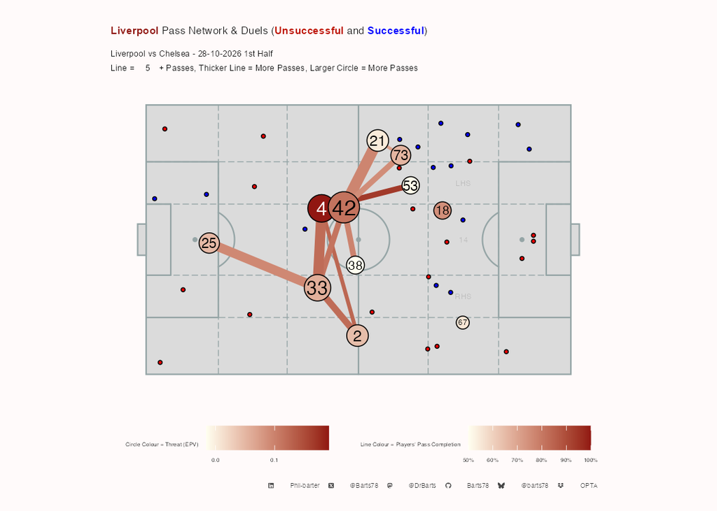

Away Pass Maps

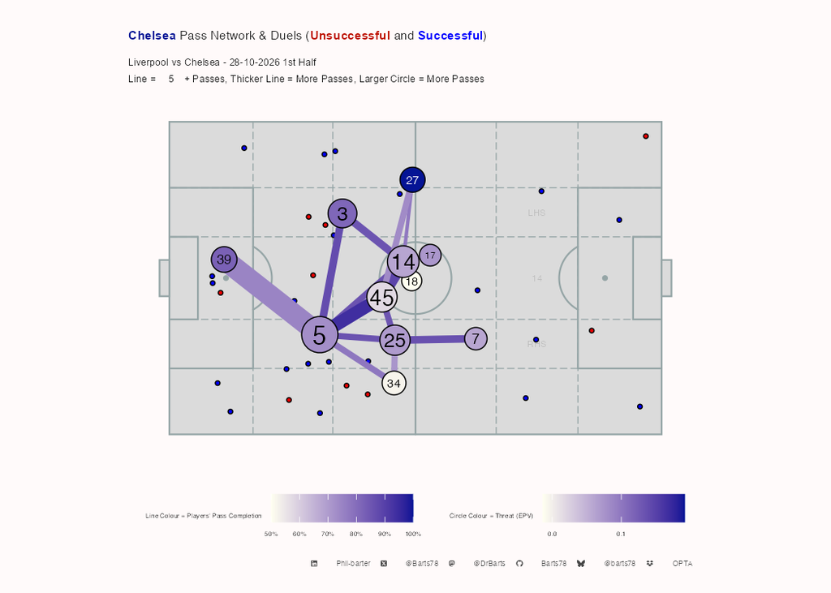

Home Pass Maps by Time

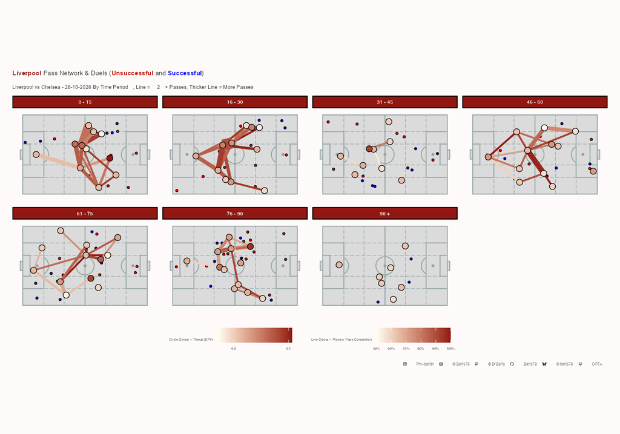

Away Pass Maps by Time

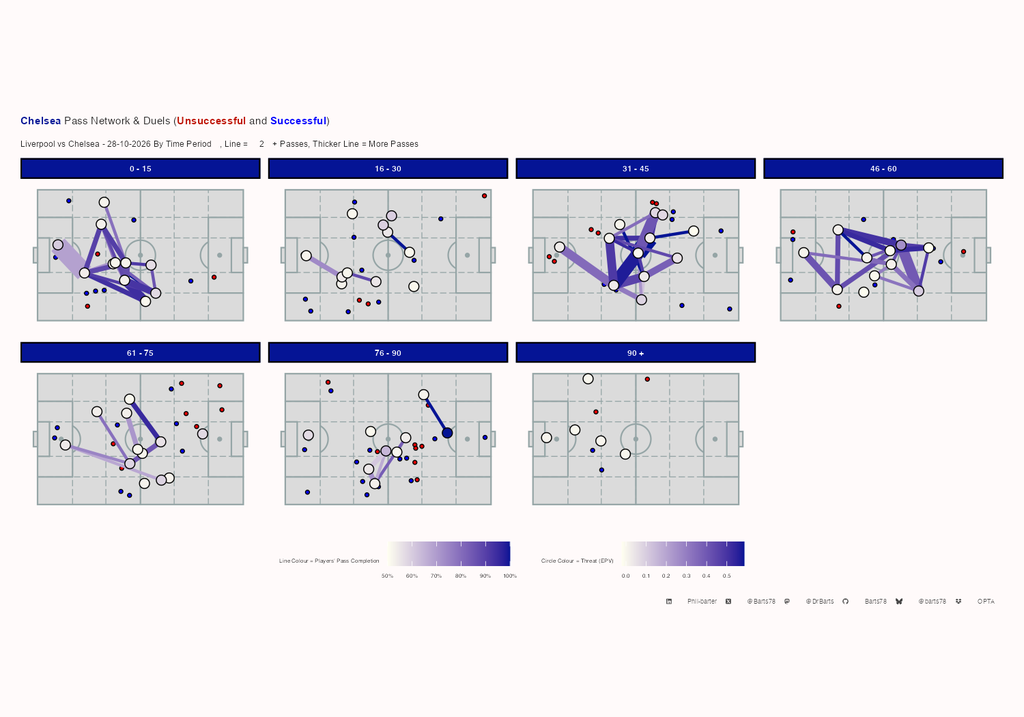

Home Attacking Pass Maps

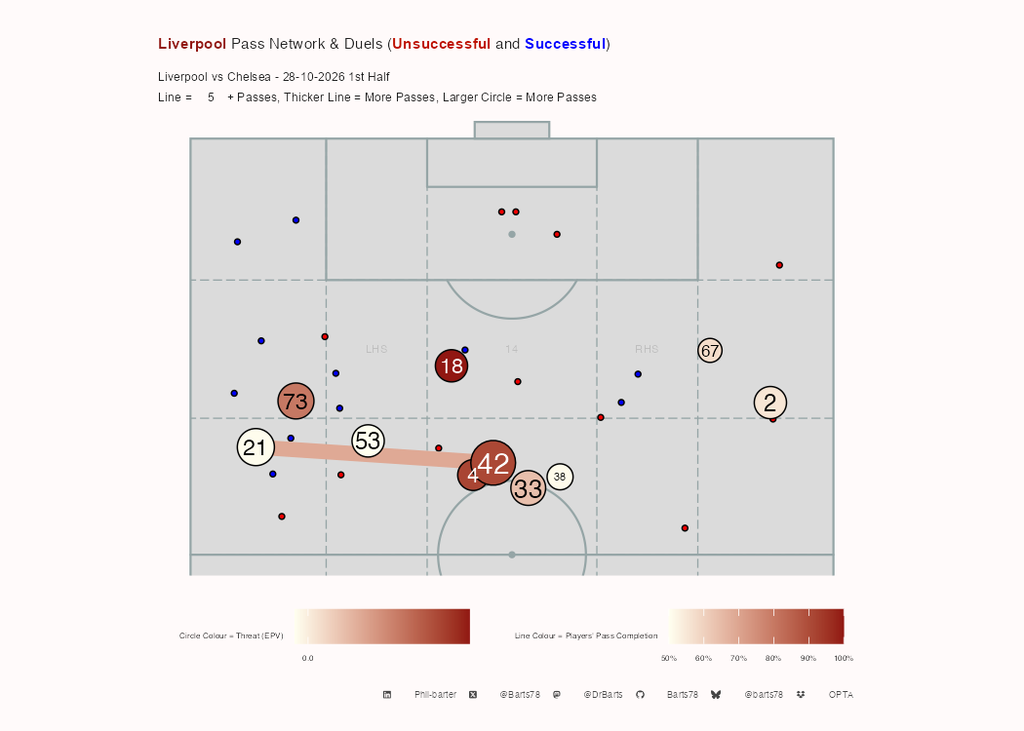

Away Attacking Pass Maps

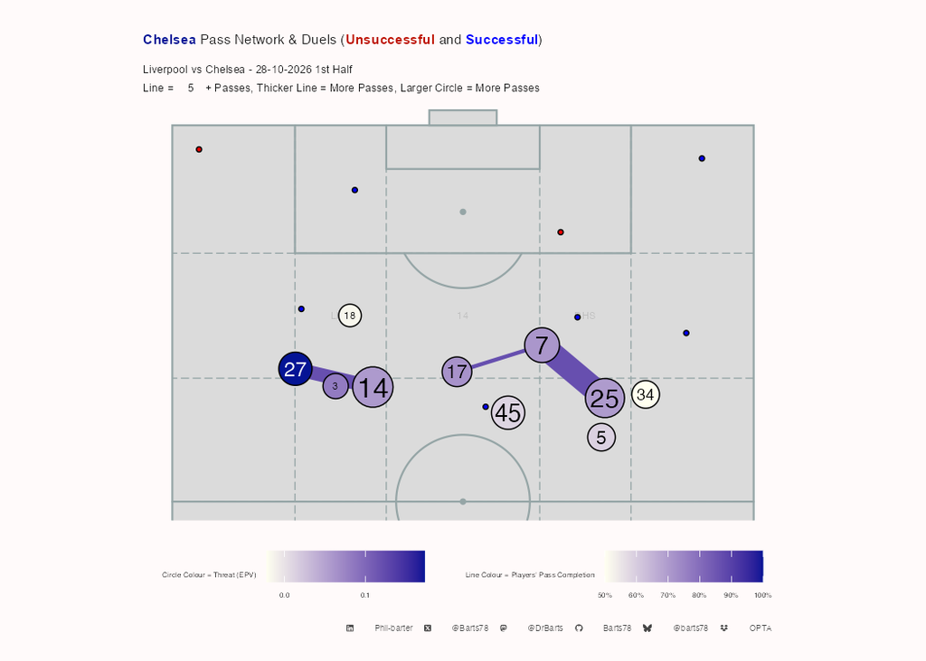

Home Attacking Pass Maps by Time

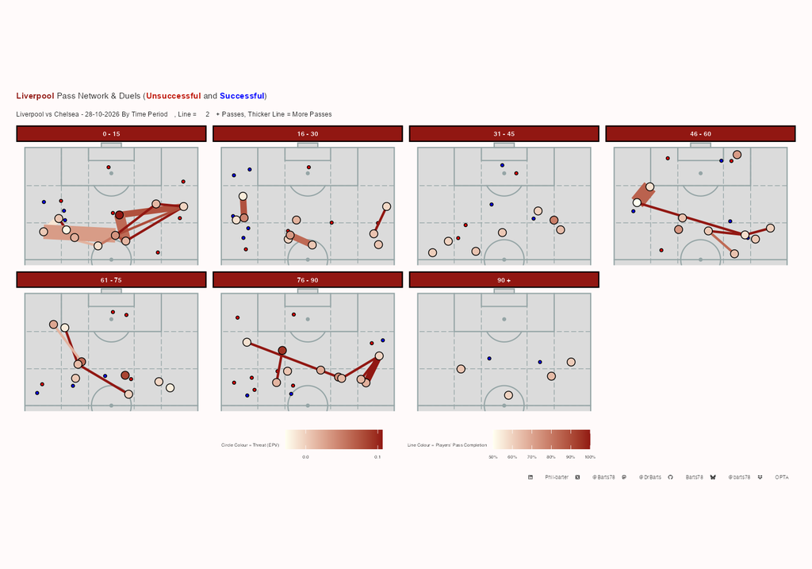

Away Attacking Pass Maps by Time

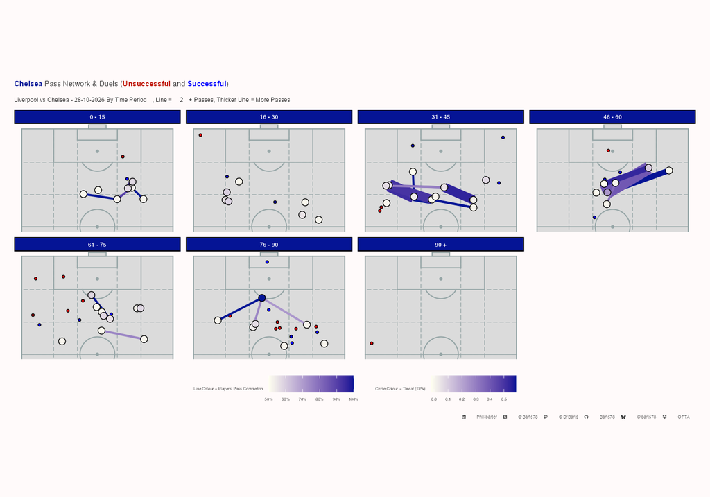

**Pass Connections by Passer**

Liverpool Open Play Passing connections

Liverpool vs Chelsea - 28-10-2026 | Completed passes only, min 5 per pair. Passer Completion % = all of the passer's attempts

|  | Completed Passes | % of Passer's Completions | % of Receiver's Receptions | Passer Completion % | Long Passes | Final Third Passes | PK Box Passes | Crosses | Key Passes | Prog Passes | EPV | EPV / Pass | Pass Time |
| --- | --- | --- | --- | --- | --- | --- | --- | --- | --- | --- | --- | --- | --- |
| Giorgi Mamardashvili |  |  |  |  |  |  |  |  |  |  |  |  |  |
| Ronald Araujo | 5 | 25% | 17% | 59% | 0 | 0 | 0 | 0 | 0 | 1 | 0.006 | 0.001 | 4.40 |
| Trey Nyoni | 5 | 25% | 9% | 59% | 0 | 0 | 0 | 0 | 0 | 0 | 0.002 | 0.000 | 3.60 |
| Joe Gomez |  |  |  |  |  |  |  |  |  |  |  |  |  |
| Ronald Araujo | 6 | 21% | 20% | 72% | 0 | 1 | 0 | 0 | 0 | 0 | 0.024 | 0.004 | 2.50 |
| Ryan Gravenberch | 5 | 17% | 19% | 72% | 0 | 0 | 0 | 0 | 0 | 0 | 0.011 | 0.002 | 2.60 |
| Kostas Tsimikas |  |  |  |  |  |  |  |  |  |  |  |  |  |
| Rio Ngumoha | 6 | 21% | 25% | 72% | 0 | 4 | 0 | 0 | 0 | 0 | 0.023 | 0.004 | 4.00 |
| Trey Nyoni | 11 | 38% | 20% | 72% | 0 | 2 | 0 | 0 | 0 | 0 | 0.032 | 0.003 | 2.45 |
| Rio Ngumoha |  |  |  |  |  |  |  |  |  |  |  |  |  |
| Kostas Tsimikas | 7 | 44% | 19% | 70% | 0 | 6 | 1 | 0 | 0 | 1 | 0.068 | 0.010 | 2.14 |
| Ronald Araujo |  |  |  |  |  |  |  |  |  |  |  |  |  |
| Giorgi Mamardashvili | 13 | 28% | 48% | 78% | 1 | 0 | 0 | 0 | 0 | 0 | 0.019 | 0.001 | 3.15 |
| Joe Gomez | 9 | 20% | 27% | 78% | 2 | 0 | 0 | 0 | 0 | 1 | 0.020 | 0.002 | 2.22 |
| Virgil van Dijk | 8 | 17% | 28% | 78% | 0 | 0 | 0 | 0 | 0 | 0 | 0.012 | 0.002 | 4.00 |
| Ryan Gravenberch |  |  |  |  |  |  |  |  |  |  |  |  |  |
| Joe Gomez | 5 | 23% | 15% | 79% | 0 | 1 | 0 | 0 | 0 | 0 | 0.005 | 0.001 | 2.40 |
| Trey Nyoni | 7 | 32% | 13% | 79% | 0 | 1 | 0 | 0 | 0 | 0 | 0.012 | 0.002 | 3.00 |
| Trey Nyoni |  |  |  |  |  |  |  |  |  |  |  |  |  |
| Kostas Tsimikas | 10 | 15% | 28% | 86% | 0 | 1 | 0 | 0 | 0 | 0 | 0.039 | 0.004 | 2.60 |
| Rio Ngumoha | 9 | 14% | 38% | 86% | 0 | 1 | 0 | 0 | 0 | 0 | 0.037 | 0.004 | 4.56 |
| Ronald Araujo | 8 | 12% | 27% | 86% | 1 | 0 | 0 | 0 | 0 | 0 | 0.015 | 0.002 | 3.62 |
| Ryan Gravenberch | 9 | 14% | 35% | 86% | 0 | 0 | 0 | 0 | 0 | 2 | 0.021 | 0.002 | 2.78 |
| Virgil van Dijk | 12 | 18% | 41% | 86% | 0 | 1 | 0 | 0 | 0 | 0 | 0.017 | 0.001 | 2.92 |
| Virgil van Dijk |  |  |  |  |  |  |  |  |  |  |  |  |  |
| Kostas Tsimikas | 5 | 12% | 14% | 87% | 2 | 0 | 0 | 0 | 0 | 0 | 0.032 | 0.006 | 4.40 |
| Ronald Araujo | 6 | 15% | 20% | 87% | 0 | 0 | 0 | 0 | 0 | 0 | 0.003 | 0.000 | 4.17 |
| Trey Nyoni | 14 | 34% | 26% | 87% | 0 | 0 | 0 | 0 | 0 | 0 | 0.016 | 0.001 | 2.50 |

X @Barts78 · Bluesky @barts78 · Mastodon @DrBarts · GitHub Barts78 · LinkedIn Phil-barter · Data: Opta

**Pass Connections by Receiver**

Liverpool Open Play Passing connections

Liverpool vs Chelsea - 28-10-2026 | Completed passes only, min 5 per pair. Passer Completion % = all of the passer's attempts

|  | Completed Passes | % of Passer's Completions | % of Receiver's Receptions | Passer Completion % | Long Passes | Final Third Passes | PK Box Passes | Crosses | Key Passes | Prog Passes | EPV | EPV / Pass | Pass Time |
| --- | --- | --- | --- | --- | --- | --- | --- | --- | --- | --- | --- | --- | --- |
| Ronald Araujo |  |  |  |  |  |  |  |  |  |  |  |  |  |
| Giorgi Mamardashvili | 5 | 25% | 17% | 59% | 0 | 0 | 0 | 0 | 0 | 1 | 0.006 | 0.001 | 4.40 |
| Joe Gomez | 6 | 21% | 20% | 72% | 0 | 1 | 0 | 0 | 0 | 0 | 0.024 | 0.004 | 2.50 |
| Trey Nyoni | 8 | 12% | 27% | 86% | 1 | 0 | 0 | 0 | 0 | 0 | 0.015 | 0.002 | 3.62 |
| Virgil van Dijk | 6 | 15% | 20% | 87% | 0 | 0 | 0 | 0 | 0 | 0 | 0.003 | 0.000 | 4.17 |
| Trey Nyoni |  |  |  |  |  |  |  |  |  |  |  |  |  |
| Giorgi Mamardashvili | 5 | 25% | 9% | 59% | 0 | 0 | 0 | 0 | 0 | 0 | 0.002 | 0.000 | 3.60 |
| Kostas Tsimikas | 11 | 38% | 20% | 72% | 0 | 2 | 0 | 0 | 0 | 0 | 0.032 | 0.003 | 2.45 |
| Ryan Gravenberch | 7 | 32% | 13% | 79% | 0 | 1 | 0 | 0 | 0 | 0 | 0.012 | 0.002 | 3.00 |
| Virgil van Dijk | 14 | 34% | 26% | 87% | 0 | 0 | 0 | 0 | 0 | 0 | 0.016 | 0.001 | 2.50 |
| Ryan Gravenberch |  |  |  |  |  |  |  |  |  |  |  |  |  |
| Joe Gomez | 5 | 17% | 19% | 72% | 0 | 0 | 0 | 0 | 0 | 0 | 0.011 | 0.002 | 2.60 |
| Trey Nyoni | 9 | 14% | 35% | 86% | 0 | 0 | 0 | 0 | 0 | 2 | 0.021 | 0.002 | 2.78 |
| Rio Ngumoha |  |  |  |  |  |  |  |  |  |  |  |  |  |
| Kostas Tsimikas | 6 | 21% | 25% | 72% | 0 | 4 | 0 | 0 | 0 | 0 | 0.023 | 0.004 | 4.00 |
| Trey Nyoni | 9 | 14% | 38% | 86% | 0 | 1 | 0 | 0 | 0 | 0 | 0.037 | 0.004 | 4.56 |
| Kostas Tsimikas |  |  |  |  |  |  |  |  |  |  |  |  |  |
| Rio Ngumoha | 7 | 44% | 19% | 70% | 0 | 6 | 1 | 0 | 0 | 1 | 0.068 | 0.010 | 2.14 |
| Trey Nyoni | 10 | 15% | 28% | 86% | 0 | 1 | 0 | 0 | 0 | 0 | 0.039 | 0.004 | 2.60 |
| Virgil van Dijk | 5 | 12% | 14% | 87% | 2 | 0 | 0 | 0 | 0 | 0 | 0.032 | 0.006 | 4.40 |
| Giorgi Mamardashvili |  |  |  |  |  |  |  |  |  |  |  |  |  |
| Ronald Araujo | 13 | 28% | 48% | 78% | 1 | 0 | 0 | 0 | 0 | 0 | 0.019 | 0.001 | 3.15 |
| Joe Gomez |  |  |  |  |  |  |  |  |  |  |  |  |  |
| Ronald Araujo | 9 | 20% | 27% | 78% | 2 | 0 | 0 | 0 | 0 | 1 | 0.020 | 0.002 | 2.22 |
| Ryan Gravenberch | 5 | 23% | 15% | 79% | 0 | 1 | 0 | 0 | 0 | 0 | 0.005 | 0.001 | 2.40 |
| Virgil van Dijk |  |  |  |  |  |  |  |  |  |  |  |  |  |
| Ronald Araujo | 8 | 17% | 28% | 78% | 0 | 0 | 0 | 0 | 0 | 0 | 0.012 | 0.002 | 4.00 |
| Trey Nyoni | 12 | 18% | 41% | 86% | 0 | 1 | 0 | 0 | 0 | 0 | 0.017 | 0.001 | 2.92 |

X @Barts78 · Bluesky @barts78 · Mastodon @DrBarts · GitHub Barts78 · LinkedIn Phil-barter · Data: Opta

**Away Pass Connections by Passer**

Chelsea Open Play Passing connections

Liverpool vs Chelsea - 28-10-2026 | Completed passes only, min 5 per pair. Passer Completion % = all of the passer's attempts

|  | Completed Passes | % of Passer's Completions | % of Receiver's Receptions | Passer Completion % | Long Passes | Final Third Passes | PK Box Passes | Crosses | Key Passes | Prog Passes | EPV | EPV / Pass | Pass Time |
| --- | --- | --- | --- | --- | --- | --- | --- | --- | --- | --- | --- | --- | --- |
| Jordan Henderson |  |  |  |  |  |  |  |  |  |  |  |  |  |
| Malo Gusto | 6 | 13% | 22% | 79% | 3 | 3 | 0 | 0 | 0 | 2 | 0.078 | 0.013 | 3.33 |
| Morgan Rogers | 5 | 11% | 17% | 79% | 0 | 2 | 0 | 0 | 1 | 3 | 0.070 | 0.014 | 2.00 |
| Pedro Neto | 5 | 11% | 17% | 79% | 0 | 2 | 0 | 0 | 0 | 1 | 0.024 | 0.005 | 3.20 |
| Roméo Lavia | 9 | 20% | 25% | 79% | 0 | 3 | 0 | 0 | 0 | 1 | 0.027 | 0.003 | 3.11 |
| Josh Acheampong |  |  |  |  |  |  |  |  |  |  |  |  |  |
| Moisés Caicedo | 5 | 36% | 18% | 61% | 0 | 2 | 0 | 0 | 0 | 2 | 0.020 | 0.004 | 2.60 |
| Malo Gusto |  |  |  |  |  |  |  |  |  |  |  |  |  |
| Roméo Lavia | 5 | 24% | 14% | 70% | 0 | 1 | 0 | 0 | 0 | 1 | 0.011 | 0.002 | 2.40 |
| Maxence Lacroix |  |  |  |  |  |  |  |  |  |  |  |  |  |
| Mike Penders | 10 | 28% | 37% | 88% | 0 | 0 | 0 | 0 | 0 | 0 | 0.012 | 0.001 | 3.90 |
| Moisés Caicedo | 5 | 14% | 18% | 88% | 0 | 0 | 0 | 0 | 0 | 0 | 0.013 | 0.003 | 1.60 |
| Pedro Neto | 5 | 14% | 17% | 88% | 0 | 0 | 0 | 0 | 0 | 2 | 0.021 | 0.004 | 2.40 |
| Mike Penders |  |  |  |  |  |  |  |  |  |  |  |  |  |
| Maxence Lacroix | 8 | 42% | 27% | 54% | 0 | 0 | 0 | 0 | 0 | 0 | 0.009 | 0.001 | 3.38 |
| Wesley Fofana | 7 | 37% | 26% | 54% | 1 | 0 | 0 | 0 | 0 | 1 | 0.023 | 0.003 | 3.29 |
| Moisés Caicedo |  |  |  |  |  |  |  |  |  |  |  |  |  |
| Josh Acheampong | 6 | 19% | 32% | 82% | 0 | 2 | 0 | 0 | 0 | 1 | 0.035 | 0.006 | 2.83 |
| Pedro Neto | 6 | 19% | 20% | 82% | 0 | 3 | 0 | 0 | 1 | 0 | 0.023 | 0.004 | 2.83 |
| Roméo Lavia | 7 | 23% | 19% | 82% | 0 | 2 | 0 | 0 | 0 | 1 | 0.005 | 0.001 | 2.57 |
| Pedro Neto |  |  |  |  |  |  |  |  |  |  |  |  |  |
| Jordan Henderson | 6 | 19% | 15% | 89% | 0 | 2 | 0 | 0 | 0 | 0 | 0.014 | 0.002 | 1.50 |
| Josh Acheampong | 5 | 16% | 26% | 89% | 0 | 2 | 0 | 0 | 1 | 0 | 0.040 | 0.008 | 2.00 |
| Moisés Caicedo | 5 | 16% | 18% | 89% | 0 | 3 | 0 | 0 | 0 | 1 | 0.026 | 0.005 | 1.60 |
| Roméo Lavia |  |  |  |  |  |  |  |  |  |  |  |  |  |
| Jordan Henderson | 8 | 20% | 20% | 91% | 0 | 1 | 0 | 0 | 0 | 0 | 0.018 | 0.002 | 2.25 |
| Malo Gusto | 6 | 15% | 22% | 91% | 0 | 1 | 0 | 0 | 0 | 1 | 0.015 | 0.002 | 2.00 |
| Maxence Lacroix | 9 | 23% | 30% | 91% | 0 | 0 | 0 | 0 | 0 | 0 | 0.014 | 0.002 | 3.33 |
| Wesley Fofana |  |  |  |  |  |  |  |  |  |  |  |  |  |
| Jordan Henderson | 7 | 18% | 17% | 83% | 0 | 1 | 0 | 0 | 0 | 0 | 0.015 | 0.002 | 2.57 |
| Maxence Lacroix | 6 | 15% | 20% | 83% | 1 | 0 | 0 | 0 | 0 | 0 | 0.006 | 0.001 | 3.67 |
| Roméo Lavia | 5 | 13% | 14% | 83% | 0 | 1 | 0 | 0 | 0 | 0 | 0.012 | 0.002 | 3.40 |

X @Barts78 · Bluesky @barts78 · Mastodon @DrBarts · GitHub Barts78 · LinkedIn Phil-barter · Data: Opta

**Away Pass Connections by Receiver**

Chelsea Open Play Passing connections

Liverpool vs Chelsea - 28-10-2026 | Completed passes only, min 5 per pair. Passer Completion % = all of the passer's attempts

|  | Completed Passes | % of Passer's Completions | % of Receiver's Receptions | Passer Completion % | Long Passes | Final Third Passes | PK Box Passes | Crosses | Key Passes | Prog Passes | EPV | EPV / Pass | Pass Time |
| --- | --- | --- | --- | --- | --- | --- | --- | --- | --- | --- | --- | --- | --- |
| Malo Gusto |  |  |  |  |  |  |  |  |  |  |  |  |  |
| Jordan Henderson | 6 | 13% | 22% | 79% | 3 | 3 | 0 | 0 | 0 | 2 | 0.078 | 0.013 | 3.33 |
| Roméo Lavia | 6 | 15% | 22% | 91% | 0 | 1 | 0 | 0 | 0 | 1 | 0.015 | 0.002 | 2.00 |
| Morgan Rogers |  |  |  |  |  |  |  |  |  |  |  |  |  |
| Jordan Henderson | 5 | 11% | 17% | 79% | 0 | 2 | 0 | 0 | 1 | 3 | 0.070 | 0.014 | 2.00 |
| Pedro Neto |  |  |  |  |  |  |  |  |  |  |  |  |  |
| Jordan Henderson | 5 | 11% | 17% | 79% | 0 | 2 | 0 | 0 | 0 | 1 | 0.024 | 0.005 | 3.20 |
| Maxence Lacroix | 5 | 14% | 17% | 88% | 0 | 0 | 0 | 0 | 0 | 2 | 0.021 | 0.004 | 2.40 |
| Moisés Caicedo | 6 | 19% | 20% | 82% | 0 | 3 | 0 | 0 | 1 | 0 | 0.023 | 0.004 | 2.83 |
| Roméo Lavia |  |  |  |  |  |  |  |  |  |  |  |  |  |
| Jordan Henderson | 9 | 20% | 25% | 79% | 0 | 3 | 0 | 0 | 0 | 1 | 0.027 | 0.003 | 3.11 |
| Malo Gusto | 5 | 24% | 14% | 70% | 0 | 1 | 0 | 0 | 0 | 1 | 0.011 | 0.002 | 2.40 |
| Moisés Caicedo | 7 | 23% | 19% | 82% | 0 | 2 | 0 | 0 | 0 | 1 | 0.005 | 0.001 | 2.57 |
| Wesley Fofana | 5 | 13% | 14% | 83% | 0 | 1 | 0 | 0 | 0 | 0 | 0.012 | 0.002 | 3.40 |
| Moisés Caicedo |  |  |  |  |  |  |  |  |  |  |  |  |  |
| Josh Acheampong | 5 | 36% | 18% | 61% | 0 | 2 | 0 | 0 | 0 | 2 | 0.020 | 0.004 | 2.60 |
| Maxence Lacroix | 5 | 14% | 18% | 88% | 0 | 0 | 0 | 0 | 0 | 0 | 0.013 | 0.003 | 1.60 |
| Pedro Neto | 5 | 16% | 18% | 89% | 0 | 3 | 0 | 0 | 0 | 1 | 0.026 | 0.005 | 1.60 |
| Mike Penders |  |  |  |  |  |  |  |  |  |  |  |  |  |
| Maxence Lacroix | 10 | 28% | 37% | 88% | 0 | 0 | 0 | 0 | 0 | 0 | 0.012 | 0.001 | 3.90 |
| Maxence Lacroix |  |  |  |  |  |  |  |  |  |  |  |  |  |
| Mike Penders | 8 | 42% | 27% | 54% | 0 | 0 | 0 | 0 | 0 | 0 | 0.009 | 0.001 | 3.38 |
| Roméo Lavia | 9 | 23% | 30% | 91% | 0 | 0 | 0 | 0 | 0 | 0 | 0.014 | 0.002 | 3.33 |
| Wesley Fofana | 6 | 15% | 20% | 83% | 1 | 0 | 0 | 0 | 0 | 0 | 0.006 | 0.001 | 3.67 |
| Wesley Fofana |  |  |  |  |  |  |  |  |  |  |  |  |  |
| Mike Penders | 7 | 37% | 26% | 54% | 1 | 0 | 0 | 0 | 0 | 1 | 0.023 | 0.003 | 3.29 |
| Josh Acheampong |  |  |  |  |  |  |  |  |  |  |  |  |  |
| Moisés Caicedo | 6 | 19% | 32% | 82% | 0 | 2 | 0 | 0 | 0 | 1 | 0.035 | 0.006 | 2.83 |
| Pedro Neto | 5 | 16% | 26% | 89% | 0 | 2 | 0 | 0 | 1 | 0 | 0.040 | 0.008 | 2.00 |
| Jordan Henderson |  |  |  |  |  |  |  |  |  |  |  |  |  |
| Pedro Neto | 6 | 19% | 15% | 89% | 0 | 2 | 0 | 0 | 0 | 0 | 0.014 | 0.002 | 1.50 |
| Roméo Lavia | 8 | 20% | 20% | 91% | 0 | 1 | 0 | 0 | 0 | 0 | 0.018 | 0.002 | 2.25 |
| Wesley Fofana | 7 | 18% | 17% | 83% | 0 | 1 | 0 | 0 | 0 | 0 | 0.015 | 0.002 | 2.57 |

X @Barts78 · Bluesky @barts78 · Mastodon @DrBarts · GitHub Barts78 · LinkedIn Phil-barter · Data: Opta

Home Passing Tree Plot

[figure not shown]

Away Passing Tree Plot

[figure not shown]

Home wave plot

[figure not shown]

Away wave plot

[figure not shown]

**Home 1st Half Pass receiving Areas**

[figure not shown]

**Home 2nd Half Pass receiving Areas**

[figure not shown]

**Home Up to 1st Sub Pass receiving Areas**

[figure not shown]

**Away 1st Half Pass receiving Areas**

[figure not shown]

**Away 2nd Half Pass receiving Areas**

[figure not shown]

**Away Up to 1st Sub Pass receiving Areas**

[figure not shown]

Home Passing chains

[figure not shown]

Away Passing Chains

[figure not shown]

**Full time**

Liverpool FT Passing Chain Length (5, 6-10, 11-15, 16 +) & Distance (m)

Liverpool vs Chelsea - 28-10-2026

|  | Pass Chain Length | Total Chain Passes | Max Chain Length | Average Chain Length | Percent of Teams Passes | Total Chain Distance | Max Chain Distance | Average Chain Distance | Percent of Teams Passing Distance |
| --- | --- | --- | --- | --- | --- | --- | --- | --- | --- |
|  | VLow | 171 | 5 | 2 | 47% | 2,347.99 | 125.86 | 13.70 | 39% |
|  | Low | 114 | 9 | 7 | 31% | 2,050.84 | 240.48 | 18.00 | 34% |
|  | Medium | 65 | 14 | 13 | 18% | 1,259.58 | 323.46 | 19.40 | 21% |
|  | High | 16 | 16 | 16 | 4% | 292.45 | 292.45 | 18.30 | 5% |
| Overall Totals | — | 366 | 44 | 38 | — | 5,951 | 982 | 69 | — |
| Overall Average | — | 92 | 11 | 10 | — | 1,488 | 246 | 17 | — |

X @Barts78 · Bluesky @barts78 · Mastodon @DrBarts · GitHub Barts78 · LinkedIn Phil-barter · Data: Opta

**1st Half**

Liverpool 1st Half Passing Chain Length (5, 6-10, 11-15, 16 +) & Distance (m)

Liverpool vs Chelsea - 28-10-2026

|  | Pass Chain Length | Total Chain Passes | Max Chain Length | Average Chain Length | Percent of Teams Passes | Total Chain Distance | Max Chain Distance | Average Chain Distance | Percent of Teams Passing Distance |
| --- | --- | --- | --- | --- | --- | --- | --- | --- | --- |
|  | VLow | 89 | 5 | 2 | 46% | 1,195.21 | 125.86 | 13.40 | 38% |
|  | Low | 39 | 8 | 7 | 20% | 706.96 | 240.48 | 18.10 | 22% |
|  | Medium | 65 | 14 | 13 | 34% | 1,259.58 | 323.46 | 19.40 | 40% |
| Overall Totals | — | 193 | 27 | 22 | — | 3,162 | 690 | 51 | — |
| Overall Average | — | 64 | 9 | 7 | — | 1,054 | 230 | 17 | — |

X @Barts78 · Bluesky @barts78 · Mastodon @DrBarts · GitHub Barts78 · LinkedIn Phil-barter · Data: Opta

**2nd Half**

Liverpool 2nd Half Passing Chain Length (5, 6-10, 11-15, 16 +) & Distance (m)

Liverpool vs Chelsea - 28-10-2026

|  | Pass Chain Length | Total Chain Passes | Max Chain Length | Average Chain Length | Percent of Teams Passes | Total Chain Distance | Max Chain Distance | Average Chain Distance | Percent of Teams Passing Distance |
| --- | --- | --- | --- | --- | --- | --- | --- | --- | --- |
|  | VLow | 82 | 5 | 2 | 47% | 1,152.78 | 87.76 | 14.10 | 41% |
|  | Low | 75 | 9 | 7 | 43% | 1,343.88 | 213.88 | 17.90 | 48% |
|  | High | 16 | 16 | 16 | 9% | 292.45 | 292.45 | 18.30 | 10% |
| Overall Totals | — | 173 | 30 | 25 | — | 2,789 | 594 | 50 | — |
| Overall Average | — | 58 | 10 | 8 | — | 930 | 198 | 17 | — |

X @Barts78 · Bluesky @barts78 · Mastodon @DrBarts · GitHub Barts78 · LinkedIn Phil-barter · Data: Opta

**Away Full time**

Chelsea FT Passing Chain Length (5, 6-10, 11-15, 16 +) & Distance (m)

Liverpool vs Chelsea - 28-10-2026

|  | Pass Chain Length | Total Chain Passes | Max Chain Length | Average Chain Length | Percent of Teams Passes | Total Chain Distance | Max Chain Distance | Average Chain Distance | Percent of Teams Passing Distance |
| --- | --- | --- | --- | --- | --- | --- | --- | --- | --- |
|  | VLow | 194 | 5 | 3 | 56% | 3,031.02 | 132.19 | 15.60 | 57% |
|  | Low | 101 | 10 | 8 | 29% | 1,567.10 | 194.81 | 15.50 | 29% |
|  | Medium | 36 | 14 | 12 | 10% | 497.47 | 196.02 | 13.80 | 9% |
|  | High | 17 | 17 | 17 | 5% | 252.53 | 252.53 | 14.90 | 5% |
| Overall Totals | — | 348 | 46 | 40 | — | 5,348 | 776 | 60 | — |
| Overall Average | — | 87 | 12 | 10 | — | 1,337 | 194 | 15 | — |

X @Barts78 · Bluesky @barts78 · Mastodon @DrBarts · GitHub Barts78 · LinkedIn Phil-barter · Data: Opta

**Away 1st Half**

Chelsea 1st Half Passing Chain Length (5, 6-10, 11-15, 16 +) & Distance (m)

Liverpool vs Chelsea - 28-10-2026

|  | Pass Chain Length | Total Chain Passes | Max Chain Length | Average Chain Length | Percent of Teams Passes | Total Chain Distance | Max Chain Distance | Average Chain Distance | Percent of Teams Passing Distance |
| --- | --- | --- | --- | --- | --- | --- | --- | --- | --- |
|  | VLow | 87 | 5 | 3 | 42% | 1,294.33 | 132.19 | 14.90 | 43% |
|  | Low | 78 | 10 | 8 | 38% | 1,167.81 | 194.81 | 15.00 | 39% |
|  | Medium | 25 | 14 | 13 | 12% | 301.45 | 193.76 | 12.10 | 10% |
|  | High | 17 | 17 | 17 | 8% | 252.53 | 252.53 | 14.90 | 8% |
| Overall Totals | — | 207 | 46 | 41 | — | 3,016 | 773 | 57 | — |
| Overall Average | — | 52 | 12 | 10 | — | 754 | 193 | 14 | — |

X @Barts78 · Bluesky @barts78 · Mastodon @DrBarts · GitHub Barts78 · LinkedIn Phil-barter · Data: Opta

**Away 2nd Half**

Chelsea 2nd Half Passing Chain Length (5, 6-10, 11-15, 16 +) & Distance (m)

Liverpool vs Chelsea - 28-10-2026

|  | Pass Chain Length | Total Chain Passes | Max Chain Length | Average Chain Length | Percent of Teams Passes | Total Chain Distance | Max Chain Distance | Average Chain Distance | Percent of Teams Passing Distance |
| --- | --- | --- | --- | --- | --- | --- | --- | --- | --- |
|  | VLow | 107 | 5 | 3 | 76% | 1,736.69 | 114.28 | 16.20 | 74% |
|  | Low | 23 | 9 | 8 | 16% | 399.29 | 169.11 | 17.40 | 17% |
|  | Medium | 11 | 11 | 11 | 8% | 196.02 | 196.02 | 17.80 | 8% |
| Overall Totals | — | 141 | 25 | 22 | — | 2,332 | 479 | 51 | — |
| Overall Average | — | 47 | 8 | 7 | — | 777 | 160 | 17 | — |

X @Barts78 · Bluesky @barts78 · Mastodon @DrBarts · GitHub Barts78 · LinkedIn Phil-barter · Data: Opta

**Home Z14 RS By Half**

[figure not shown]

**Home Z14 RS By Game Period**

[figure not shown]

**Away Z14 RS By Half**

[figure not shown]

**Away Z14 RS By Game Period**

[figure not shown]

**Home Long Passes By half**

[figure not shown]

**Home Long Passes By Game Period**

[figure not shown]

**Away Long Passes By Half**

[figure not shown]

**Away Long Passes By Game period**

[figure not shown]

Set-Piece Summary

**Set Pieces**

Liverpool vs Chelsea - 28-10-2026

|  | Liverpool | Chelsea |
| --- | --- | --- |
| Corners |  |  |
| Corners taken | 7 | 5 |
| Short | 0 | 2 |
| Direct | 7 | 3 |
| Direct - first contact won | 2 (29%) | 1 (33%) |
| Free kicks |  |  |
| Free kicks (passes) | 11 | 11 |
| Into final third / box | 4 | 5 |
| Into box | 2 | 2 |
| Throw-ins |  |  |
| Throw-ins | 14 | 18 |
| Retained (first touch) | 57% | 50% |
| Shots by situation |  |  |
| Open-play shots | 4 | 7 |
| Open-play xG | 0.76 | 0.62 |
| Open-play goals | 0 | 0 |
| Set-piece shots | 5 | 3 |
| Set-piece xG | 0.57 | 0.41 |
| Set-piece goals | 0 | 0 |
| Penalties | 1 | 1 |
| Penalty xG | 0.79 | 0.79 |
| Set-piece share of xG | 27% | 23% |

First contact: the team that touches the ball first after the delivery (aerial duels go to the winner). Throw-ins retained = first touch by the taking team.  
X @Barts78 · Bluesky @barts78 · Mastodon @DrBarts · GitHub Barts78 · LinkedIn Phil-barter · Data: Opta

**Corners**

[figure not shown]

**Free Kicks**

[figure not shown]

**Corners**

[figure not shown]

**Free Kicks**

[figure not shown]

**Sequence Map**

[figure not shown]

**Sequence Table**

**Liverpool - Shot-Creating Sequences**

Liverpool vs Chelsea - 28-10-2026

| Min | Shooter | Result | xG | Situation | Started by | Started from | Start zone | Passes | Duration (s) |
| --- | --- | --- | --- | --- | --- | --- | --- | --- | --- |
| 31' | Araujo | Blocked | 0.03 | Set piece | Araujo | Open-play regain | Att third, Central | 0 | 0 |
| 41' | Nyoni | Blocked | 0.03 | Set piece | Gomez | Throw-in | Att third, Right wing | 1 | 4 |
| 42' | van Dijk | Blocked | 0.04 | Set piece | Tsimikas | Corner | Att third, Left wing | 1 | 1 |
| 43' | Gakpo | Goal | 0.79 | Penalty | Tsimikas | Corner | Att third, Left wing | 1 | 81 |
| 44' | Gakpo | Saved | 0.06 | Open play | Gakpo | Open-play regain | Mid third, Left half-space | 0 | 2 |
| 45+2' | Araujo | Off target | 0.09 | Set piece | Tsimikas | Corner | Att third, Left wing | 1 | 3 |
| 61' | Araujo | Saved | 0.38 | Set piece | Gomez | Throw-in | Att third, Right wing | 3 | 9 |
| 65' | Barcola | Saved | 0.11 | Open play | Barcola | Open-play regain | Mid third, Right wing | 4 | 17 |
| 80' | Wirtz | Blocked | 0.33 | Open play | Jacquet | Open-play regain | Def third, Left half-space | 12 | 82 |
| 80' | Barcola | Blocked | 0.26 | Open play | Jacquet | Open-play regain | Def third, Left half-space | 12 | 83 |

X @Barts78 · Bluesky @barts78 · Mastodon @DrBarts · GitHub Barts78 · LinkedIn Phil-barter · Data: Opta

**Sequence Map**

[figure not shown]

**Sequence Table**

**Chelsea - Shot-Creating Sequences**

Liverpool vs Chelsea - 28-10-2026

| Min | Shooter | Result | xG | Situation | Started by | Started from | Start zone | Passes | Duration (s) |
| --- | --- | --- | --- | --- | --- | --- | --- | --- | --- |
| 22' | Caicedo | Off target | 0.04 | Set piece | Henderson | Free kick | Mid third, Left half-space | 2 | 4 |
| 40' | Rogers | Goal | 0.79 | Penalty | Lavia | Open-play regain | Mid third, Right wing | 8 | 150 |
| 48' | Rogers | Saved | 0.13 | Open play | Rogers | Open-play regain | Att third, Central | 0 | 0 |
| 53' | Rogers | Blocked | 0.03 | Open play | Gusto | Open-play regain | Att third, Left wing | 1 | 4 |
| 53' | Neto | Saved | 0.02 | Open play | Gusto | Open-play regain | Att third, Left wing | 3 | 12 |
| 55' | Rogers | Blocked | 0.02 | Open play | Gusto | Throw-in | Mid third, Left wing | 4 | 10 |
| 61' | Rogers | Blocked | 0.14 | Open play | Caicedo | Open-play regain | Def third, Central | 1 | 8 |
| 67' | Rogers | Off target | 0.04 | Set piece | Rogers | Open-play regain | Def third, Right half-space | 5 | 107 |
| 75' | Acheampong | Off target | 0.02 | Open play | Penders | Keeper | Def third, Central | 8 | 26 |
| 78' | Palestra | Saved | 0.26 | Open play | Neto | Open-play regain | Att third, Right half-space | 2 | 4 |
| 78' | Colwill | Off target | 0.33 | Set piece | Henderson | Corner | Att third, Left wing | 1 | 2 |

X @Barts78 · Bluesky @barts78 · Mastodon @DrBarts · GitHub Barts78 · LinkedIn Phil-barter · Data: Opta

Entries by Channel

**Box and Final-Third Entries (open play)**

Liverpool vs Chelsea - 28-10-2026

|  | Box entries Passes | Box entries Carries | Box entries Total | Box entries Success % | Final-third entries Passes | Final-third entries Carries | Final-third entries Total | Final-third entries Success % |
| --- | --- | --- | --- | --- | --- | --- | --- | --- |
| Liverpool |  |  |  |  |  |  |  |  |
| Left wing | 7 | 1 | 8 | 25% | 12 | 1 | 13 | 46% |
| Left half-space | 2 | 1 | 3 | 33% | 9 | 4 | 13 | 100% |
| Central | 2 | 0 | 2 | 0% | 11 | 3 | 14 | 64% |
| Right half-space | 1 | 0 | 1 | 0% | 11 | 1 | 12 | 83% |
| Right wing | 4 | 1 | 5 | 60% | 7 | 2 | 9 | 56% |
| Total | 16 | 3 | 19 | 32% | 50 | 11 | 61 | 70% |
| Chelsea |  |  |  |  |  |  |  |  |
| Left wing | 5 | 1 | 6 | 33% | 4 | 3 | 7 | 29% |
| Left half-space | 2 | 2 | 4 | 50% | 9 | 1 | 10 | 60% |
| Central | 13 | 0 | 13 | 46% | 13 | 1 | 14 | 57% |
| Right half-space | 6 | 0 | 6 | 67% | 10 | 1 | 11 | 64% |
| Right wing | 1 | 2 | 3 | 33% | 3 | 2 | 5 | 80% |
| Total | 27 | 5 | 32 | 47% | 39 | 8 | 47 | 57% |

Channel = where the pass or carry started. Left/right from the attacking team's view. Set pieces excluded.  
X @Barts78 · Bluesky @barts78 · Mastodon @DrBarts · GitHub Barts78 · LinkedIn Phil-barter · Data: Opta

**Box**

[figure not shown]

**Final Third**

[figure not shown]

**Box**

[figure not shown]

**Final Third**

[figure not shown]

**Match Stats**

**Passing stats**

Liverpool vs Chelsea - 28-10-2026

|  | Name | Mins | % of Team Possession | xA | xT | Attempted Passes | Successful Passes | Pass Success % | Assists | BCs | Key Passes | Long Ps | Final 3rd P | Prog Ps | PK Box P | Pass Received | PPs Received | KPs Recieved | Recieveing Suc | EPV Recieved | EPV Created | % of Team EPV |
| --- | --- | --- | --- | --- | --- | --- | --- | --- | --- | --- | --- | --- | --- | --- | --- | --- | --- | --- | --- | --- | --- | --- |
| Keeper | Giorgi Mamardashvili | 111 | 0.07 | 0 | 0 | 34 | 20 | 0.59 | 0 | 0 | 0 | 19 | 0 | 1 | 0 | 33 | 0 | 0 | 0.818181818181818 | 0.387 | 0.035 | 0.02 |
| Defender | Joe Gomez | 111 | 0.1 | 0 | 0.29 | 41 | 29 | 0.71 | 0 | 0 | 1 | 5 | 7 | 1 | 0 | 44 | 2 | 0 | 0.772727272727273 | 0.181 | 0.299 | 0.14 |
| Defender | Kostas Tsimikas | 111 | 0.11 | 0 | 0.6 | 40 | 29 | 0.72 | 0 | 0 | 2 | 2 | 13 | 0 | 0 | 51 | 2 | 0 | 0.745098039215686 | 0.304 | 0.645 | 0.29 |
| Defender | Ronald Araujo | 111 | 0.12 | 0.24 | 0.06 | 59 | 46 | 0.78 | 0 | 1 | 0 | 9 | 1 | 6 | 0 | 50 | 1 | 0 | 0.6 | 0.968 | 0.132 | 0.06 |
| Defender | Virgil van Dijk | 76 | 0.09 | 0.07 | 0.08 | 47 | 41 | 0.87 | 0 | 0 | 0 | 5 | 2 | 5 | 0 | 43 | 1 | 0 | 0.697674418604651 | 0.217 | 0.157 | 0.07 |
| Defender | Jérémy Jacquet | 35 | 0.03 | 0 | 0.01 | 16 | 13 | 0.81 | 0 | 0 | 0 | 1 | 1 | 1 | 0 | 13 | 0 | 0 | 0.692307692307692 | 0.08 | 0.026 | 0.01 |
| Midfielder | Ryan Gravenberch | 111 | 0.07 | 0 | 0.02 | 28 | 22 | 0.79 | 0 | 0 | 0 | 2 | 4 | 1 | 0 | 30 | 5 | 0 | 0.866666666666667 | 0.107 | 0.065 | 0.03 |
| Midfielder | Rio Ngumoha | 86 | 0.06 | 0 | 0.12 | 23 | 16 | 0.7 | 0 | 0 | 0 | 1 | 15 | 2 | 2 | 25 | 1 | 0 | 0.96 | 0.137 | 0.115 | 0.05 |
| Midfielder | Trey Nyoni | 85 | 0.14 | 0 | 0.07 | 76 | 65 | 0.86 | 0 | 0 | 0 | 7 | 8 | 7 | 0 | 67 | 1 | 0 | 0.82089552238806 | 0.335 | 0.177 | 0.08 |
| Midfielder | James McConnell | 63 | 0.03 | 0 | 0.04 | 11 | 11 | 1 | 0 | 0 | 0 | 1 | 4 | 1 | 0 | 13 | 5 | 0 | 1 | 0.06 | 0.06 | 0.03 |

[output cut: 6 more lines]

X @Barts78 · Bluesky @barts78 · Mastodon @DrBarts · GitHub Barts78 · LinkedIn Phil-barter · Data: Opta

**Touches and Carries**

Liverpool vs Chelsea - 28-10-2026

|  | Name | Mins | Touches | Def 3rd | Mid 3rd | Final 3rd | PK Box | Total / Min | Def 3rd % TT | Mid Third % TT | Final 3rd % TT | PK Box % TT | Carries | % Carries Prog | % Carries F 3rd | % Carries D Prog | Total Dribbles | Dribbles Won | Dribbles Lost | Dribble Success |
| --- | --- | --- | --- | --- | --- | --- | --- | --- | --- | --- | --- | --- | --- | --- | --- | --- | --- | --- | --- | --- |
| Keeper | Giorgi Mamardashvili | 111 | 45 | 44 | 1 | 0 | 0 | 0.405405405405405 | 0.977777777777778 | 0.0222222222222222 | 0 | 0 | 7 | 0 | 0 | 0 | 0 | 0 | 0 | 0 |
| Defender | Joe Gomez | 111 | 65 | 22 | 26 | 17 | 0 | 0.585585585585586 | 0.338461538461538 | 0.4 | 0.261538461538462 | 0 | 7 | 0 | 0 | 0 | 1 | 1 | 0 | 1 |
| Defender | Kostas Tsimikas | 111 | 68 | 18 | 23 | 27 | 2 | 0.612612612612613 | 0.264705882352941 | 0.338235294117647 | 0.397058823529412 | 0.0294117647058824 | 6 | 0.166666666666667 | 0.666666666666667 | 0.187681862269641 | 0 | 0 | 0 | 0 |
| Defender | Ronald Araujo | 111 | 77 | 33 | 39 | 5 | 4 | 0.693693693693694 | 0.428571428571429 | 0.506493506493506 | 0.0649350649350649 | 0.051948051948052 | 8 | 0.125 | 0.25 | 0.107555555555556 | 0 | 0 | 0 | 0 |
| Defender | Virgil van Dijk | 76 | 54 | 13 | 38 | 3 | 1 | 0.710526315789474 | 0.240740740740741 | 0.703703703703704 | 0.0555555555555556 | 0.0185185185185185 | 10 | 0 | 0.1 | 0 | 0 | 0 | 0 | 0 |
| Defender | Jérémy Jacquet | 35 | 18 | 9 | 8 | 1 | 0 | 0.514285714285714 | 0.5 | 0.444444444444444 | 0.0555555555555556 | 0 | 0 | 0 | 0 | 0 | 0 | 0 | 0 | 0 |
| Midfielder | Ryan Gravenberch | 111 | 41 | 7 | 25 | 9 | 0 | 0.369369369369369 | 0.170731707317073 | 0.609756097560976 | 0.219512195121951 | 0 | 6 | 0 | 0 | 0 | 1 | 0 | 1 | 0 |
| Midfielder | Rio Ngumoha | 86 | 38 | 5 | 10 | 23 | 4 | 0.441860465116279 | 0.131578947368421 | 0.263157894736842 | 0.605263157894737 | 0.105263157894737 | 2 | 0 | 0.5 | 0 | 4 | 4 | 0 | 1 |
| Midfielder | Trey Nyoni | 85 | 86 | 18 | 58 | 10 | 0 | 1.01176470588235 | 0.209302325581395 | 0.674418604651163 | 0.116279069767442 | 0 | 21 | 0 | 0.19047619047619 | 0 | 0 | 0 | 0 | 0 |
| Midfielder | James McConnell | 63 | 20 | 2 | 11 | 7 | 1 | 0.317460317460317 | 0.1 | 0.55 | 0.35 | 0.05 | 3 | 0 | 0.666666666666667 | 0 | 0 | 0 | 0 | 0 |

[output cut: 6 more lines]

X @Barts78 · Bluesky @barts78 · Mastodon @DrBarts · GitHub Barts78 · LinkedIn Phil-barter · Data: Opta

**Shooting stats**

Liverpool vs Chelsea - 28-10-2026

|  | Name | Mins | Total Shots | SoT | 6 yard box | PK Box Shot | Out Box Shots | Blocked Shot | Goals | xG | xGOT | xG/Shot | Shot Accuracy | Shot Quality |
| --- | --- | --- | --- | --- | --- | --- | --- | --- | --- | --- | --- | --- | --- | --- |
| Keeper | Giorgi Mamardashvili | 111 | 0 | 0 | 0 | 0 | 0 | 0 | 0 | 0 | 0 | 0 | 0 | 0 |
| Defender | Joe Gomez | 111 | 0 | 0 | 0 | 0 | 0 | 0 | 0 | 0 | 0 | 0 | 0 | 0 |
| Defender | Kostas Tsimikas | 111 | 0 | 0 | 0 | 0 | 0 | 0 | 0 | 0 | 0 | 0 | 0 | 0 |
| Defender | Ronald Araujo | 111 | 3 | 1 | 0 | 3 | 0 | 1 | 0 | 0.5 | 0.5 | 0.166666666666667 | 0.333333333333333 | 0 |
| Defender | Virgil van Dijk | 76 | 1 | 0 | 0 | 1 | 0 | 1 | 0 | 0.04 | 0 | 0.04 | 0 | -1 |
| Defender | Jérémy Jacquet | 35 | 0 | 0 | 0 | 0 | 0 | 0 | 0 | 0 | 0 | 0 | 0 | 0 |
| Midfielder | Ryan Gravenberch | 111 | 0 | 0 | 0 | 0 | 0 | 0 | 0 | 0 | 0 | 0 | 0 | 0 |
| Midfielder | Rio Ngumoha | 86 | 0 | 0 | 0 | 0 | 0 | 0 | 0 | 0 | 0 | 0 | 0 | 0 |
| Midfielder | Trey Nyoni | 85 | 1 | 0 | 0 | 0 | 1 | 1 | 0 | 0.03 | 0 | 0.03 | 0 | -1 |
| Midfielder | James McConnell | 63 | 0 | 0 | 0 | 0 | 0 | 0 | 0 | 0 | 0 | 0 | 0 | 0 |

[output cut: 6 more lines]

X @Barts78 · Bluesky @barts78 · Mastodon @DrBarts · GitHub Barts78 · LinkedIn Phil-barter · Data: Opta

**Defensive stats**

Liverpool vs Chelsea - 28-10-2026

|  | Name | Mins | Aerials Total | Aerials Won | Aerial Success % | Duels Total | Duels Won | Duel Success | Tackles Total | Tackles Won | Tackles Lost | Interceptions Total | Recoverys Total | Clearances Total | Fouls Total | Fouls Conceeded | Fouls Received | Offside Won | Offside Lost | EPV Faced | EPV Won | EPV Lost | Possession Control | Poss Control /100 Touches |
| --- | --- | --- | --- | --- | --- | --- | --- | --- | --- | --- | --- | --- | --- | --- | --- | --- | --- | --- | --- | --- | --- | --- | --- | --- |
| Keeper | Giorgi Mamardashvili | 111 | 0 | 0 | 0 | 1 | 1 | 1 | 0 | 0 | 0 | 0 | 1 | 1 | 0 | 0 | 0 | 0 | 0 | 0.014 | 1 | 0 | -13 | -28.9 |
| Defender | Joe Gomez | 111 | 6 | 2 | 0.333333333333333 | 9 | 4 | 0.444444444444444 | 3 | 2 | 1 | 0 | 7 | 0 | 3 | 1 | 2 | 2 | 0 | 0.013 | 0.846153846153846 | 0.153846153846154 | -10 | -15.4 |
| Defender | Kostas Tsimikas | 111 | 1 | 0 | 0 | 4 | 0 | 0 | 2 | 0 | 2 | 2 | 4 | 1 | 2 | 2 | 0 | 0 | 0 | 0.036 | 0.888888888888889 | 0.111111111111111 | -17 | -25 |
| Defender | Ronald Araujo | 111 | 8 | 5 | 0.625 | 1 | 0 | 0 | 1 | 0 | 1 | 3 | 7 | 10 | 0 | 0 | 0 | 1 | 0 | 0.119 | 1 | 0 | -4 | -5.2 |
| Defender | Virgil van Dijk | 76 | 0 | 0 | 0 | 0 | 0 | 0 | 0 | 0 | 0 | 3 | 1 | 1 | 0 | 0 | 0 | 0 | 0 | 0.016 | 1 | 0 | -3 | -5.6 |
| Defender | Jérémy Jacquet | 35 | 1 | 1 | 1 | 1 | 0 | 0 | 0 | 0 | 0 | 0 | 1 | 0 | 1 | 1 | 0 | 0 | 0 | 0.001 | 0 | 1 | -2 | -11.1 |
| Midfielder | Ryan Gravenberch | 111 | 2 | 1 | 0.5 | 8 | 2 | 0.25 | 3 | 2 | 1 | 0 | 1 | 0 | 2 | 1 | 1 | 0 | 1 | 0.004 | 0.75 | 0.25 | -11 | -26.8 |
| Midfielder | Rio Ngumoha | 86 | 1 | 0 | 0 | 10 | 8 | 0.8 | 1 | 1 | 0 | 0 | 3 | 1 | 3 | 0 | 3 | 0 | 0 | 0.019 | 1 | 0 | -9 | -23.7 |
| Midfielder | Trey Nyoni | 85 | 1 | 1 | 1 | 6 | 1 | 0.166666666666667 | 4 | 2 | 2 | 4 | 4 | 0 | 1 | 0 | 1 | 0 | 0 | 0.039 | 0.769230769230769 | 0.230769230769231 | -4 | -4.7 |
| Midfielder | James McConnell | 63 | 1 | 0 | 0 | 6 | 2 | 0.333333333333333 | 3 | 2 | 1 | 0 | 3 | 1 | 1 | 1 | 0 | 0 | 0 | 0.023 | 1 | 0 | -1 | -5 |

[output cut: 6 more lines]

Greyed Poss Control /100 Touches = fewer than 20 touches. | X @Barts78 · Bluesky @barts78 · Mastodon @DrBarts · GitHub Barts78 · LinkedIn Phil-barter · Data: Opta

**Season Totals**

**Passing stats**

Season totals up to Liverpool vs Chelsea - 28-10-2026

|  | Name | Mins | % of Team Possession | xA | xT | Attempted Passes | Successful Passes | Pass Success % | Assists | BCs | Key Passes | Long Ps | Final 3rd P | Prog Ps | PK Box P | Pass Received | PPs Received | KPs Recieved | Recieveing Suc | EPV Recieved | EPV Created | % of Team EPV |
| --- | --- | --- | --- | --- | --- | --- | --- | --- | --- | --- | --- | --- | --- | --- | --- | --- | --- | --- | --- | --- | --- | --- |
| Keeper | Giorgi Mamardashvili | 210 | 0.08 | 0 | 0.04 | 71 | 44 | 0.62 | 0 | 0 | 1 | 36 | 0 | 1 | 0 | 62 | 0 | 0 | 0.806451612903226 | 0.647 | 0.106 | 0.03 |
| Defender | Ronald Araujo | 210 | 0.12 | 0.24 | 0.1 | 117 | 96 | 0.82 | 0 | 1 | 0 | 15 | 4 | 8 | 0 | 96 | 1 | 0 | 0.708333333333333 | 1.112 | 0.239 | 0.06 |
| Defender | Joe Gomez | 161 | 0.09 | 0 | 0.34 | 73 | 57 | 0.78 | 0 | 0 | 1 | 13 | 7 | 2 | 0 | 76 | 2 | 0 | 0.789473684210526 | 0.377 | 0.379 | 0.09 |
| Defender | Kostas Tsimikas | 111 | 0.06 | 0 | 0.6 | 40 | 29 | 0.72 | 0 | 0 | 2 | 2 | 13 | 0 | 0 | 51 | 2 | 0 | 0.745098039215686 | 0.304 | 0.645 | 0.16 |
| Defender | Jeremie Frimpong | 99 | 0.04 | 0 | 0.06 | 30 | 25 | 0.83 | 0 | 0 | 0 | 2 | 6 | 1 | 0 | 33 | 1 | 0 | 0.696969696969697 | 0.197 | 0.096 | 0.02 |
| Defender | Milos Kerkez | 99 | 0.05 | 0 | 0.37 | 29 | 24 | 0.83 | 0 | 0 | 0 | 6 | 8 | 1 | 1 | 31 | 3 | 1 | 0.774193548387097 | 0.256 | 0.497 | 0.12 |
| Defender | Jérémy Jacquet | 84 | 0.04 | 0 | 0.15 | 39 | 33 | 0.85 | 0 | 0 | 0 | 6 | 2 | 5 | 1 | 36 | 0 | 0 | 0.75 | 0.144 | 0.148 | 0.04 |
| Defender | Virgil van Dijk | 76 | 0.04 | 0.07 | 0.08 | 47 | 41 | 0.87 | 0 | 0 | 0 | 5 | 2 | 5 | 0 | 43 | 1 | 0 | 0.697674418604651 | 0.217 | 0.157 | 0.04 |
| Midfielder | Rio Ngumoha | 162 | 0.05 | 0 | 0.18 | 33 | 24 | 0.73 | 0 | 0 | 1 | 2 | 21 | 5 | 2 | 43 | 2 | 0 | 0.953488372093023 | 0.231 | 0.23 | 0.06 |
| Midfielder | Trey Nyoni | 151 | 0.11 | 0 | 0.23 | 115 | 102 | 0.89 | 0 | 0 | 0 | 9 | 13 | 15 | 0 | 97 | 1 | 0 | 0.845360824742268 | 0.398 | 0.374 | 0.09 |

[output cut: 9 more lines]

X @Barts78 · Bluesky @barts78 · Mastodon @DrBarts · GitHub Barts78 · LinkedIn Phil-barter · Data: Opta

**Touches and Carries**

Season totals up to Liverpool vs Chelsea - 28-10-2026

|  | Name | Mins | Touches | Def 3rd | Mid 3rd | Final 3rd | PK Box | Total / Min | Def 3rd % TT | Mid Third % TT | Final 3rd % TT | PK Box % TT | Carries | % Carries Prog | % Carries F 3rd | % Carries D Prog | Total Dribbles | Dribbles Won | Dribbles Lost | Dribble Success |
| --- | --- | --- | --- | --- | --- | --- | --- | --- | --- | --- | --- | --- | --- | --- | --- | --- | --- | --- | --- | --- |
| Keeper | Giorgi Mamardashvili | 210 | 95 | 94 | 1 | 0 | 0 | 0.452380952380952 | 0.989473684210526 | 0.0105263157894737 | 0 | 0 | 37 | 0 | 0 | 0 | 0 | 0 | 0 | 0 |
| Defender | Ronald Araujo | 210 | 144 | 62 | 73 | 9 | 4 | 0.685714285714286 | 0.430555555555556 | 0.506944444444444 | 0.0625 | 0.0277777777777778 | 53 | 0.0754716981132075 | 0.113207547169811 | 0.0503589810600286 | 0 | 0 | 0 | 0 |
| Defender | Joe Gomez | 161 | 109 | 49 | 40 | 20 | 0 | 0.677018633540373 | 0.44954128440367 | 0.36697247706422 | 0.18348623853211 | 0 | 26 | 0 | 0.0384615384615385 | 0 | 1 | 1 | 0 | 1 |
| Defender | Kostas Tsimikas | 111 | 68 | 18 | 23 | 27 | 2 | 0.612612612612613 | 0.264705882352941 | 0.338235294117647 | 0.397058823529412 | 0.0294117647058824 | 6 | 0.166666666666667 | 0.666666666666667 | 0.187681862269641 | 0 | 0 | 0 | 0 |
| Defender | Jeremie Frimpong | 99 | 54 | 14 | 32 | 8 | 0 | 0.545454545454545 | 0.259259259259259 | 0.592592592592593 | 0.148148148148148 | 0 | 23 | 0.130434782608696 | 0.217391304347826 | 0.0914039464731232 | 0 | 0 | 0 | 0 |
| Defender | Milos Kerkez | 99 | 57 | 21 | 22 | 14 | 1 | 0.575757575757576 | 0.368421052631579 | 0.385964912280702 | 0.245614035087719 | 0.0175438596491228 | 26 | 0.153846153846154 | 0.384615384615385 | 0.134390679193184 | 0 | 0 | 0 | 0 |
| Defender | Jérémy Jacquet | 84 | 48 | 19 | 27 | 2 | 1 | 0.571428571428571 | 0.395833333333333 | 0.5625 | 0.0416666666666667 | 0.0208333333333333 | 17 | 0 | 0 | 0 | 0 | 0 | 0 | 0 |
| Defender | Virgil van Dijk | 76 | 54 | 13 | 38 | 3 | 1 | 0.710526315789474 | 0.240740740740741 | 0.703703703703704 | 0.0555555555555556 | 0.0185185185185185 | 10 | 0 | 0.1 | 0 | 0 | 0 | 0 | 0 |
| Midfielder | Rio Ngumoha | 162 | 62 | 6 | 18 | 38 | 5 | 0.382716049382716 | 0.0967741935483871 | 0.290322580645161 | 0.612903225806452 | 0.0806451612903226 | 6 | 0.166666666666667 | 0.666666666666667 | 0.188011443017763 | 6 | 5 | 1 | 0.833333333333333 |
| Midfielder | Trey Nyoni | 151 | 134 | 30 | 88 | 16 | 0 | 0.887417218543046 | 0.223880597014925 | 0.656716417910448 | 0.119402985074627 | 0 | 53 | 0.0188679245283019 | 0.169811320754717 | 0.0215918426521046 | 0 | 0 | 0 | 0 |

[output cut: 9 more lines]

X @Barts78 · Bluesky @barts78 · Mastodon @DrBarts · GitHub Barts78 · LinkedIn Phil-barter · Data: Opta

**Shooting stats**

Season totals up to Liverpool vs Chelsea - 28-10-2026

|  | Name | Mins | Total Shots | SoT | 6 yard box | PK Box Shot | Out Box Shots | Blocked Shot | Goals | xG | xGOT | xG/Shot | Shot Accuracy | Shot Quality |
| --- | --- | --- | --- | --- | --- | --- | --- | --- | --- | --- | --- | --- | --- | --- |
| Keeper | Giorgi Mamardashvili | 210 | 0 | 0 | 0 | 0 | 0 | 0 | 0 | 0 | 0 | 0 | 0 | 0 |
| Defender | Ronald Araujo | 210 | 3 | 1 | 0 | 3 | 0 | 1 | 0 | 0.5 | 0.5 | 0.166666666666667 | 0.333333333333333 | 0 |
| Defender | Joe Gomez | 161 | 0 | 0 | 0 | 0 | 0 | 0 | 0 | 0 | 0 | 0 | 0 | 0 |
| Defender | Kostas Tsimikas | 111 | 0 | 0 | 0 | 0 | 0 | 0 | 0 | 0 | 0 | 0 | 0 | 0 |
| Defender | Jeremie Frimpong | 99 | 0 | 0 | 0 | 0 | 0 | 0 | 0 | 0 | 0 | 0 | 0 | 0 |
| Defender | Milos Kerkez | 99 | 0 | 0 | 0 | 0 | 0 | 0 | 0 | 0 | 0 | 0 | 0 | 0 |
| Defender | Jérémy Jacquet | 84 | 0 | 0 | 0 | 0 | 0 | 0 | 0 | 0 | 0 | 0 | 0 | 0 |
| Defender | Virgil van Dijk | 76 | 1 | 0 | 0 | 1 | 0 | 1 | 0 | 0.04 | 0 | 0.04 | 0 | -1 |
| Midfielder | Rio Ngumoha | 162 | 0 | 0 | 0 | 0 | 0 | 0 | 0 | 0 | 0 | 0 | 0 | 0 |
| Midfielder | Trey Nyoni | 151 | 2 | 0 | 0 | 0 | 2 | 2 | 0 | 0.05 | 0 | 0.025 | 0 | -1 |

[output cut: 9 more lines]

X @Barts78 · Bluesky @barts78 · Mastodon @DrBarts · GitHub Barts78 · LinkedIn Phil-barter · Data: Opta

**Defensive stats**

Season totals up to Liverpool vs Chelsea - 28-10-2026

|  | Name | Mins | Aerials Total | Aerials Won | Aerial Success % | Duels Total | Duels Won | Duel Success | Tackles Total | Tackles Won | Tackles Lost | Interceptions Total | Recoverys Total | Clearances Total | Fouls Total | Fouls Conceeded | Fouls Received | Offside Won | Offside Lost | EPV Faced | EPV Won | EPV Lost | Possession Control | Poss Control /100 Touches |
| --- | --- | --- | --- | --- | --- | --- | --- | --- | --- | --- | --- | --- | --- | --- | --- | --- | --- | --- | --- | --- | --- | --- | --- | --- |
| Keeper | Giorgi Mamardashvili | 210 | 0 | 0 | 0 | 3 | 3 | 1 | 0 | 0 | 0 | 0 | 3 | 1 | 1 | 1 | 0 | 0 | 0 | 0.002 | 1 | 0 | -24 | -25.3 |
| Defender | Ronald Araujo | 210 | 9 | 6 | 0.666666666666667 | 2 | 0 | 0 | 1 | 0 | 1 | 4 | 13 | 15 | 1 | 0 | 1 | 1 | 0 | 0.234 | 1 | 0 | -4 | -2.8 |
| Defender | Joe Gomez | 161 | 7 | 2 | 0.285714285714286 | 10 | 4 | 0.4 | 4 | 2 | 2 | 1 | 8 | 4 | 3 | 1 | 2 | 2 | 0 | 0.037 | 0.837837837837838 | 0.162162162162162 | -16 | -14.7 |
| Defender | Kostas Tsimikas | 111 | 1 | 0 | 0 | 4 | 0 | 0 | 2 | 0 | 2 | 2 | 4 | 1 | 2 | 2 | 0 | 0 | 0 | 0.004 | 0 | 1 | -17 | -25 |
| Defender | Jeremie Frimpong | 99 | 1 | 1 | 1 | 9 | 4 | 0.444444444444444 | 5 | 5 | 0 | 2 | 4 | 3 | 3 | 0 | 3 | 2 | 0 | 0.057 | 0.947368421052632 | 0.0526315789473684 | 2 | 3.7 |
| Defender | Milos Kerkez | 99 | 3 | 1 | 0.333333333333333 | 8 | 3 | 0.375 | 3 | 2 | 1 | 1 | 0 | 5 | 4 | 1 | 3 | 1 | 0 | 0.015 | 1 | 0 | -8 | -14 |
| Defender | Jérémy Jacquet | 84 | 1 | 1 | 1 | 3 | 2 | 0.666666666666667 | 2 | 2 | 0 | 1 | 3 | 3 | 1 | 1 | 0 | 0 | 0 | 0.012 | 0.916666666666667 | 0.0833333333333333 | 0 | 0 |
| Defender | Virgil van Dijk | 76 | 0 | 0 | 0 | 0 | 0 | 0 | 0 | 0 | 0 | 3 | 1 | 1 | 0 | 0 | 0 | 0 | 0 | 0.003 | 1 | 0 | -3 | -5.6 |
| Midfielder | Rio Ngumoha | 162 | 1 | 0 | 0 | 16 | 11 | 0.6875 | 3 | 3 | 0 | 1 | 4 | 1 | 4 | 1 | 3 | 0 | 0 | 0.002 | 0.5 | 0.5 | -16 | -25.8 |
| Midfielder | Trey Nyoni | 151 | 2 | 2 | 1 | 10 | 2 | 0.2 | 7 | 5 | 2 | 5 | 10 | 2 | 1 | 0 | 1 | 0 | 0 | 0.052 | 0.480769230769231 | 0.519230769230769 | 3 | 2.2 |

[output cut: 9 more lines]

Greyed Poss Control /100 Touches = fewer than 20 touches. | X @Barts78 · Bluesky @barts78 · Mastodon @DrBarts · GitHub Barts78 · LinkedIn Phil-barter · Data: Opta

**Season P90**

**Passing stats**

Season per 90 up to Liverpool vs Chelsea - 28-10-2026 | greyed rows < 90 mins

|  | Name | Mins | % of Team Possession | xA | xT | Attempted Passes | Successful Passes | Pass Success % | Assists | BCs | Key Passes | Long Ps | Final 3rd P | Prog Ps | PK Box P | Pass Received | PPs Received | KPs Recieved | Recieveing Suc | EPV Recieved | EPV Created | % of Team EPV |
| --- | --- | --- | --- | --- | --- | --- | --- | --- | --- | --- | --- | --- | --- | --- | --- | --- | --- | --- | --- | --- | --- | --- |
| Keeper | Giorgi Mamardashvili | 210 | 0.08 | 0 | 0.02 | 30.43 | 18.86 | 0.62 | 0 | 0 | 0.43 | 15.43 | 0 | 0.43 | 0 | 26.57 | 0 | 0 | 0.806451612903226 | 0.28 | 0.05 | 0.03 |
| Defender | Ronald Araujo | 210 | 0.12 | 0.1 | 0.04 | 50.14 | 41.14 | 0.82 | 0 | 0.43 | 0 | 6.43 | 1.71 | 3.43 | 0 | 41.14 | 0.43 | 0 | 0.708333333333333 | 0.48 | 0.1 | 0.06 |
| Defender | Joe Gomez | 161 | 0.09 | 0 | 0.19 | 40.81 | 31.86 | 0.78 | 0 | 0 | 0.56 | 7.27 | 3.91 | 1.12 | 0 | 42.48 | 1.12 | 0 | 0.789473684210526 | 0.21 | 0.21 | 0.09 |
| Defender | Kostas Tsimikas | 111 | 0.06 | 0 | 0.49 | 32.43 | 23.51 | 0.72 | 0 | 0 | 1.62 | 1.62 | 10.54 | 0 | 0 | 41.35 | 1.62 | 0 | 0.745098039215686 | 0.25 | 0.52 | 0.16 |
| Defender | Jeremie Frimpong | 99 | 0.04 | 0 | 0.05 | 27.27 | 22.73 | 0.83 | 0 | 0 | 0 | 1.82 | 5.45 | 0.91 | 0 | 30 | 0.91 | 0 | 0.696969696969697 | 0.18 | 0.09 | 0.02 |
| Defender | Milos Kerkez | 99 | 0.05 | 0 | 0.34 | 26.36 | 21.82 | 0.83 | 0 | 0 | 0 | 5.45 | 7.27 | 0.91 | 0.91 | 28.18 | 2.73 | 0.91 | 0.774193548387097 | 0.23 | 0.45 | 0.12 |
| Defender | Jérémy Jacquet | 84 | 0.04 | 0 | 0.16 | 41.79 | 35.36 | 0.85 | 0 | 0 | 0 | 6.43 | 2.14 | 5.36 | 1.07 | 38.57 | 0 | 0 | 0.75 | 0.15 | 0.16 | 0.04 |
| Defender | Virgil van Dijk | 76 | 0.04 | 0.08 | 0.09 | 55.66 | 48.55 | 0.87 | 0 | 0 | 0 | 5.92 | 2.37 | 5.92 | 0 | 50.92 | 1.18 | 0 | 0.697674418604651 | 0.26 | 0.19 | 0.04 |
| Midfielder | Rio Ngumoha | 162 | 0.05 | 0 | 0.1 | 18.33 | 13.33 | 0.73 | 0 | 0 | 0.56 | 1.11 | 11.67 | 2.78 | 1.11 | 23.89 | 1.11 | 0 | 0.953488372093023 | 0.13 | 0.13 | 0.06 |
| Midfielder | Trey Nyoni | 151 | 0.11 | 0 | 0.14 | 68.54 | 60.79 | 0.89 | 0 | 0 | 0 | 5.36 | 7.75 | 8.94 | 0 | 57.81 | 0.6 | 0 | 0.845360824742268 | 0.24 | 0.22 | 0.09 |

[output cut: 9 more lines]